# [프로젝트] 민법 기반 Multi-Node 실험형 Legal Agent

## [실습 구현] 3-1. 민법 PDF 로드 및 parse_law_v3 파서

민법은 기존 3개 법률과 달리 **편 > 장 > 절 > (관) > 조** 의 다단계 구조이므로 `parse_law`(장 기준), `parse_law_v2`(장 없음 대응)를 확장한 `parse_law_v3` 를 구현합니다.

- 반환 구조: `{"서문": str, "편": {편제목: {장제목: {절제목: [조문...]}}}, "부칙": str}`
- 절이 없는 장은 절 키를 `"_"` 로 통일 / 부칙이 없으면 빈 문자열 (현재 PDF 는 본문 전용이라 부칙 없음)

```python
# 선행 셀: 없음 (독립 실행 가능 — data/civil_law.pdf 필요)
import re
import random
from langchain_community.document_loaders import PyPDFLoader

pdf_file_civil = 'data/civil_law.pdf'

loader = PyPDFLoader(pdf_file_civil, mode='single')
pages_civil = loader.load()

# 헤더/푸터 제거: "법제처  N  국가법령정보센터 / 민법"
# (PDF 텍스트 추출 시 '국가법령정보센터'가 줄바꿈으로 갈라지는 경우까지 허용)
text_for_delete_civil = r"법제처\s+\d+\s+국가법령정보센\s*터\s*\n?\s*민법"
civil_law_text = "\n".join(
    [re.sub(text_for_delete_civil, "", p.page_content).strip() for p in pages_civil]
)


def parse_law_v3(law_text):
    """'편 > 장 > 절 > (관) > 조' 다단계 구조 법령 파서 (민법 대응).

    - parse_law(장 기준), parse_law_v2(장 없음 대응) 의 확장판
    - 반환: {"서문": str, "편": {편제목: {장제목: {절제목: [조문...]}}}, "부칙": str}
    - 절이 없는 장은 절 키를 "_" 로 통일하여 구조 일관성 유지
    - 부칙이 없으면 빈 문자열
    """
    # 부칙 분리 ('부칙' 단독 라인 기준, 없으면 빈 문자열)
    appendix = ""
    m = re.search(r'(?m)^\s*부칙\s*(?:<[^>]*>)?\s*$', law_text)
    if m:
        appendix = law_text[m.start():].strip()
        law_text = law_text[:m.start()]

    # 조 분리 패턴 — 기존 parse_law 와 동일한 아이디어
    article_pattern = r'(제\d+조(?:의\d+)?\s*\([^)]+\).*?)(?=제\d+조(?:의\d+)?\s*\([^)]+\)|$)'

    def split_articles(text):
        # '제N관 ...' 소제목 라인은 조문 본문을 오염시키지 않도록 제거
        text = re.sub(r'(?m)^\s*제\d+관\s+\S[^\n]*$', '', text)
        return [a.strip() for a in re.findall(article_pattern, text, re.DOTALL)]

    # 편 단위 분리: 줄 전체가 '제N편 제목' 인 라인 기준
    # ('제1편의 규정...' 같은 본문 내 참조는 편 번호 뒤 공백 필수 조건으로 배제)
    parts = re.split(r'(?m)^\s*(제\d+편\s+\S[^\n]*?)\s*$', law_text)
    parsed = {"서문": parts[0].strip(), "편": {}, "부칙": appendix}

    # parts = [서문, 편제목1, 편본문1, 편제목2, 편본문2, ...]
    for i in range(1, len(parts), 2):
        pyeon_title = re.sub(r'\s+', ' ', parts[i]).strip()
        pyeon_body = parts[i + 1]
        parsed["편"][pyeon_title] = {}

        # 장 단위 분리 (장이 없는 편은 장 키 "_")
        jang_parts = re.split(r'(?m)^\s*(제\d+장\s+\S[^\n]*?)\s*$', pyeon_body)
        if len(jang_parts) == 1:
            parsed["편"][pyeon_title]["_"] = {"_": split_articles(pyeon_body)}
            continue

        for j in range(1, len(jang_parts), 2):
            jang_title = re.sub(r'\s+', ' ', jang_parts[j]).strip()
            jang_body = jang_parts[j + 1]
            parsed["편"][pyeon_title][jang_title] = {}

            # 절 단위 분리 (절이 없는 장은 절 키 "_")
            jeol_parts = re.split(r'(?m)^\s*(제\d+절\s+\S[^\n]*?)\s*$', jang_body)
            if len(jeol_parts) == 1:
                parsed["편"][pyeon_title][jang_title]["_"] = split_articles(jang_body)
            else:
                # 절 시작 전에 장 직속 조문이 있으면 "_" 절로 수용
                head_articles = split_articles(jeol_parts[0])
                if head_articles:
                    parsed["편"][pyeon_title][jang_title]["_"] = head_articles
                for k in range(1, len(jeol_parts), 2):
                    jeol_title = re.sub(r'\s+', ' ', jeol_parts[k]).strip()
                    parsed["편"][pyeon_title][jang_title][jeol_title] = split_articles(jeol_parts[k + 1])

    return parsed


def flatten_civil_law(parsed):
    """parse_law_v3 결과를 조문 단위 dict 리스트로 평탄화."""
    flat = []
    for pyeon, jangs in parsed["편"].items():
        for jang, jeols in jangs.items():
            for jeol, articles in jeols.items():
                for article in articles:
                    no_m = re.match(r'(제\d+조(?:의\d+)?)', article)
                    title_m = re.match(r'제\d+조(?:의\d+)?\s*\(([^)]+)\)', article)
                    flat.append({
                        "part": pyeon,
                        "chapter": jang,
                        "section": jeol,
                        "article_no": no_m.group(1) if no_m else "",
                        "article_title": f"({title_m.group(1)})" if title_m else "",
                        "article": article,
                    })
    return flat


parsed_civil_law = parse_law_v3(civil_law_text)
flat_civil_articles = flatten_civil_law(parsed_civil_law)

print(f"편 개수: {len(parsed_civil_law['편'])}")
print(f"편 목록: {list(parsed_civil_law['편'].keys())}")
print(f"조문 개수(평탄화): {len(flat_civil_articles)}")
```

```
편 개수: 5
편 목록: ['제1편 총칙', '제2편 물권', '제3편 채권', '제4편 친족', '제5편 상속 <개정 1990. 1. 13.>']
조문 개수(평탄화): 1117
```

## [실습 구현] 3-2. 파싱 품질 검증

- 편/장/절/조 개수, 원문 `제N조(` 매치 대비 커버리지(95% 이상), 조문 길이 분포, 8000자 초과 조문, 무작위 샘플 3개

```python
# 선행 셀: 3-1 (parsed_civil_law, flat_civil_articles, civil_law_text)
import statistics

# 편/장/절/조 개수
n_jang = sum(len(j) for j in parsed_civil_law["편"].values())
n_jeol = sum(len(s) for j in parsed_civil_law["편"].values() for s in j.values())
print(f"편 {len(parsed_civil_law['편'])} / 장 {n_jang} / 절 {n_jeol} / 조 {len(flat_civil_articles)}")

# 원문 대비 조문 커버리지 (95% 이상이어야 함)
raw_article_count = len(re.findall(r'제\d+조(?:의\d+)?\s*\(', civil_law_text))
coverage = len(flat_civil_articles) / raw_article_count * 100
print(f"원문 '제N조(' 매치: {raw_article_count} → 파싱 커버리지: {coverage:.1f}%")
assert coverage >= 95, "커버리지 95% 미만 — 정규식 보정 필요"

# 조문 길이 분포
lengths = [len(a["article"]) for a in flat_civil_articles]
print(f"조문 길이 min/max/평균/중앙값: {min(lengths)} / {max(lengths)} / "
      f"{statistics.mean(lengths):.0f} / {statistics.median(lengths):.0f}")

# 8000자 초과 조문 목록
long_articles = [a for a in flat_civil_articles if len(a["article"]) > 8000]
print(f"8000자 초과 조문: {[(a['article_no'], len(a['article'])) for a in long_articles]}")

# 무작위 3개 조문 샘플
random.seed(42)
for a in random.sample(flat_civil_articles, 3):
    print("-" * 80)
    print(f"[{a['part']} > {a['chapter']} > {a['section']}] {a['article_no']}{a['article_title']}")
    print(a["article"][:200])
```

```
편 5 / 장 32 / 절 85 / 조 1117
원문 '제N조(' 매치: 1117 → 파싱 커버리지: 100.0%
조문 길이 min/max/평균/중앙값: 24 / 1340 / 143 / 114
8000자 초과 조문: []
--------------------------------------------------------------------------------
[제2편 물권 > 제3장 소유권 > 제1절 소유권의 한계] 제226조(여수소통권)
제226조(여수소통권) ①고지소유자는 침수지를 건조하기 위하여 또는 가용이나 농, 공업용의
여수를 소통하기 위하여 공로, 공류 또는 하수도에 달하기까지 저지에 물을 통과하게 할 수
있다.
②전항의 경우에는 저지의 손해가 가장 적은 장소와 방법을 선택하여야 하며 손해를 보상하
여야 한다.
--------------------------------------------------------------------------------
[제1편 총칙 > 제3장 법인 > 제2절 설립] 제51조(사무소 이전의 등기)
제51조(사무소 이전의 등기) ① 법인이 주사무소를 이전한 경우에는 종전 소재지 또는 새 소재
지에서 3주일 내에 새 소재지와 이전 연월일을 등기하여야 한다.
② 법인이 분사무소를 이전한 경우에는 주사무소 소재지에서 3주일 내에 새 소재지와 이전
연월일을 등기하여야 한다.
[전문개정 2024. 9. 20.]
--------------------------------------------------------------------------------
[제3편 채권 > 제2장 계약 > 제2절 증여] 제557조(증여자의 재산상태변경과 증여의 해제)
제557조(증여자의 재산상태변경과 증여의 해제) 증여계약후에 증여자의 재산상태가 현저히 변
경되고 그 이행으로 인하여 생계에 중대한 영향을 미칠 경우에는 증여자는 증여를 해제할 수
있다.
```

## [실습 구현] 3-3. 조문 Document 변환 + 장문 분할

기존 개인정보보호법 Document 변환 셀 형식을 따르되, 메타데이터를 편/장/절/조문번호로 확장합니다. 8000자 초과 조문만 `RecursiveCharacterTextSplitter`(chunk_size=4000, overlap=200)로 분할하고 `chunk_index` 를 부여합니다.

```python
# 선행 셀: 3-1 (flat_civil_articles, pdf_file_civil)
from langchain_core.documents import Document
from langchain_text_splitters import RecursiveCharacterTextSplitter

final_docs_civil = []
for item in flat_civil_articles:
    # metadata 구성 — 기존 개인정보보호법 변환 셀 형식 + 편/장/절/조문번호 확장
    metadata = {
        "source": pdf_file_civil,
        "name": "민법",
        "part": item["part"],
        "chapter": item["chapter"],
        "section": item["section"],
        "article_no": item["article_no"],
        "article_title": item["article_title"],
    }

    # "_" (해당 계층 없음) 는 출처 표기에서 제외
    location = " ".join(v for v in (item["part"], item["chapter"], item["section"]) if v != "_")
    content = (
        f"<출처>\n다음 조항은 **민법** 본문의 **{location}**에서 발췌한 내용입니다.\n</출처>\n\n"
        f"<법률조항>\n{item['article']}\n</법률조항>"
    )
    final_docs_civil.append(Document(page_content=content, metadata=metadata))

# 8000자 초과 조문만 분할 (chunk_size=4000, overlap=200)
splitter_civil = RecursiveCharacterTextSplitter(chunk_size=4000, chunk_overlap=200)
split_docs = []
for doc in final_docs_civil:
    if len(doc.page_content) > 8000:
        chunks = splitter_civil.split_text(doc.page_content)
        for ci, chunk in enumerate(chunks):
            split_docs.append(Document(page_content=chunk, metadata={**doc.metadata, "chunk_index": ci}))
    else:
        split_docs.append(doc)
final_docs_civil = split_docs

print(f"final_docs_civil 문서 수: {len(final_docs_civil)}")
print("-" * 80)
sample = final_docs_civil[0]
print(sample.page_content[:300])
print(sample.metadata)
```

```
final_docs_civil 문서 수: 1117
--------------------------------------------------------------------------------
<출처>
다음 조항은 **민법** 본문의 **제1편 총칙 제1장 통칙**에서 발췌한 내용입니다.
</출처>

<법률조항>
제1조(법원) 민사에 관하여 법률에 규정이 없으면 관습법에 의하고 관습법이 없으면 조리에 의
한다.
</법률조항>
{'source': 'data/civil_law.pdf', 'name': '민법', 'part': '제1편 총칙', 'chapter': '제1장 통칙', 'section': '_', 'article_no': '제1조', 'article_title': '(법원)'}
```

## [실습 구현] 4-1. 민법 벡터 저장소 (Chroma `civil_law` 컬렉션)

기존 컬렉션 생성 셀 패턴을 따르되, 문서가 1,117개로 많으므로

- 이미 컬렉션이 존재하면(count > 0) 재생성하지 않고 **로드만** 하는 가드
- 200개 배치 `add_documents` + 진행률 출력
- 실행 전 임베딩 비용/시간 예상치 출력

```python
# 선행 셀: 3-3 (final_docs_civil)
import time
from langchain_chroma import Chroma
from langchain_openai import OpenAIEmbeddings

embeddings_model = OpenAIEmbeddings(model="text-embedding-3-small")

# 컬렉션 핸들 생성 (존재하지 않으면 빈 컬렉션)
civil_db = Chroma(
    embedding_function=embeddings_model,
    collection_name="civil_law",
    persist_directory="./chroma_db",
)

existing_count = civil_db._collection.count()
if existing_count > 0:
    # 이미 임베딩되어 있으면 재생성하지 않고 로드만
    print(f"기존 'civil_law' 컬렉션 로드 — 문서 {existing_count}개 (재생성 생략)")
else:
    # 임베딩 비용/시간 예상치 (text-embedding-3-small: $0.02 / 1M tokens, 한글 약 1.3자/토큰 가정)
    total_chars = sum(len(d.page_content) for d in final_docs_civil)
    est_tokens = int(total_chars / 1.3)
    print(f"임베딩 예상: 문서 {len(final_docs_civil)}개, {total_chars:,}자 ≈ {est_tokens:,} tokens")
    print(f"예상 비용 ≈ ${est_tokens / 1_000_000 * 0.02:.4f}, 예상 시간 ≈ {len(final_docs_civil) // 200 + 1}배치 × 수 초")

    # 200개 배치로 나눠 add_documents + 진행률 출력
    BATCH = 200
    t0 = time.perf_counter()
    for i in range(0, len(final_docs_civil), BATCH):
        batch = final_docs_civil[i:i + BATCH]
        civil_db.add_documents(batch)
        print(f"  진행률: {min(i + BATCH, len(final_docs_civil))}/{len(final_docs_civil)} "
              f"({time.perf_counter() - t0:.1f}s)")
    print(f"완료 — 총 {civil_db._collection.count()}개 문서 임베딩 ({time.perf_counter() - t0:.1f}s)")
```

```
기존 'civil_law' 컬렉션 로드 — 문서 1117개 (재생성 생략)
```

## [실습 구현] 4-2. 리트리버 3종 (basic / mmr / rerank)

STEP 6 실험 프레임워크에서 전환해 가며 비교할 리트리버 3종을 나란히 준비합니다. `cross_reranker` 는 0-3 셀에서 이미 정의된 것을 재사용합니다.

```python
# 선행 셀: 4-1 (civil_db) / 0-3 (cross_reranker)
from langchain_classic.retrievers import ContextualCompressionRetriever

# cross_reranker 가 정의되어 있지 않으면 새로 생성 (기존 도구 정의 셀과 동일 설정)
if "cross_reranker" not in globals():
    from langchain_classic.retrievers.document_compressors import CrossEncoderReranker
    from langchain_community.cross_encoders import HuggingFaceCrossEncoder

    rerank_model = HuggingFaceCrossEncoder(
        model_name="BAAI/bge-reranker-v2-m3",
        model_kwargs={"device": "cpu", "trust_remote_code": True},
    )
    cross_reranker = CrossEncoderReranker(model=rerank_model, top_n=4)

# 1) 기본 유사도 검색 (k=5)
civil_retriever_basic = civil_db.as_retriever(search_kwargs={"k": 5})

# 2) MMR 다양성 검색
civil_retriever_mmr = civil_db.as_retriever(
    search_type="mmr",
    search_kwargs={"k": 5, "fetch_k": 20, "lambda_mult": 0.5},
)

# 3) CrossEncoder Re-rank (k=10 → top 4)
civil_retriever_rerank = ContextualCompressionRetriever(
    base_compressor=cross_reranker,
    base_retriever=civil_db.as_retriever(search_kwargs={"k": 10}),
)

# 기존 네이밍(*_db_retriever)을 따르는 기본 리트리버 = rerank
civil_db_retriever = civil_retriever_rerank
print("리트리버 3종 준비 완료: civil_retriever_basic / civil_retriever_mmr / civil_retriever_rerank")
```

```
리트리버 3종 준비 완료: civil_retriever_basic / civil_retriever_mmr / civil_retriever_rerank
```

## [실습 구현] 4-3. 민법 검색 도구 정의 + tools 목록 갱신

- `civil_law_search`: 기존 `personal_law_search` 와 동일한 시그니처/폴백 패턴
- `civil_article_lookup`: "제839조의2" 같은 조문 번호를 metadata 필터로 정확 조회
- `tools` 목록에 민법 도구 2종 추가

```python
# 선행 셀: 4-2 (civil_db_retriever) / 0-3 (기존 도구 4종)
from langchain.tools import tool
from langchain_core.documents import Document
from typing import List


@tool
def civil_law_search(query: str) -> List[Document]:
    """민법 법률 조항을 검색합니다. (계약, 채권·채무, 소유권·물권, 불법행위, 손해배상, 혼인·이혼·친권, 상속·유언 등)"""
    docs = civil_db_retriever.invoke(query)

    if len(docs) > 0:
        return docs

    return [Document(page_content="**민법 검색**에서 관련 정보를 찾을 수 없습니다.", metadata={"source": "data/civil_law.pdf", "name": "민법"})]


@tool
def civil_article_lookup(article_no: str) -> List[Document]:
    """민법 조문 번호(예: '제839조의2', '제5조')로 해당 조문 원문을 정확히 조회합니다."""
    # 입력 정규화: 공백 제거, '제'/'조' 보정 ("839" → "제839조")
    no = article_no.strip().replace(" ", "")
    if not no.startswith("제"):
        no = "제" + no
    if not (no.endswith("조") or "조의" in no):
        no = no + "조"

    result = civil_db.get(where={"article_no": no})
    docs = [
        Document(page_content=content, metadata=meta)
        for content, meta in zip(result["documents"], result["metadatas"])
    ]

    if len(docs) > 0:
        return docs

    return [Document(page_content=f"**민법 조문 조회**에서 '{article_no}' 조문을 찾을 수 없습니다.", metadata={"source": "data/civil_law.pdf", "name": "민법"})]


# 도구 목록 갱신 — 기존 4종 + 민법 2종
tools = [personal_law_search, labor_law_search, housing_law_search,
         civil_law_search, civil_article_lookup, web_search]
print("tools:", [t.name for t in tools])
```

```
tools: ['personal_law_search', 'labor_law_search', 'housing_law_search', 'civil_law_search', 'civil_article_lookup', 'web_search']
```

## [실습 구현] 4-4. 리트리버 3종 비교 검증

4개 테스트 질의에 대해 (리트리버, 조문번호, 앞 120자, 소요시간)을 표로 비교합니다. 관련 조문이 top-4 안에 나오는지 확인합니다.

```python
# 선행 셀: 4-2 (리트리버 3종)
import time
import pandas as pd

civil_test_queries = [
    "이혼 시 재산분할 청구권은 언제까지 행사할 수 있나요?",
    "미성년자가 법정대리인 동의 없이 한 계약은 효력이 있나요?",
    "전세권과 임차권의 차이는 무엇인가요?",
    "매도인의 하자담보책임 존속기간은?",
]

civil_retrievers = {
    "basic": civil_retriever_basic,
    "mmr": civil_retriever_mmr,
    "rerank": civil_retriever_rerank,
}

rows = []
for q in civil_test_queries:
    for name, retriever in civil_retrievers.items():
        t0 = time.perf_counter()
        docs = retriever.invoke(q)
        elapsed = time.perf_counter() - t0
        for rank, d in enumerate(docs[:4], 1):
            # <법률조항> 태그 안의 본문에서 앞 120자 추출
            body = d.page_content.split("<법률조항>")[-1].replace("</법률조항>", "").strip()
            rows.append({
                "질의": q[:20] + "…",
                "리트리버": name,
                "순위": rank,
                "조문번호": d.metadata.get("article_no", "?"),
                "본문(앞 120자)": body[:120].replace("\n", " "),
                "소요시간(s)": round(elapsed, 2),
            })

civil_retriever_report = pd.DataFrame(rows)
pd.set_option("display.max_colwidth", 60)
print(civil_retriever_report.to_string(index=False))
```

```
                   질의   리트리버  순위    조문번호                                                                                                               본문(앞 120자)  소요시간(s)
이혼 시 재산분할 청구권은 언제까지 …  basic   1 제839조의2 제839조의2(재산분할청구권) ①협의상 이혼한 자의 일방은 다른 일방에 대하여 재산분할을 청 구할 수 있다. ②제1항의 재산분할에 관하여 협의가 되지 아니하거나 협의할 수 없는 때에는 가정법원은 당사자의 청구에 의하     1.20
이혼 시 재산분할 청구권은 언제까지 …  basic   2 제839조의3 제839조의3(재산분할청구권 보전을 위한 사해행위취소권) ① 부부의 일방이 다른 일방의 재산 분할청구권 행사를 해함을 알면서도 재산권을 목적으로 하는 법률행위를 한 때에는 다른 일 방은 제406조제1항을 준용하여 그     1.20
이혼 시 재산분할 청구권은 언제까지 …  basic   3   제841조       제841조(부정으로 인한 이혼청구권의 소멸) 전조제1호의 사유는 다른 일방이 사전동의나 사후 용서를 한 때 또는 이를 안 날로부터 6월, 그 사유있은 날로부터 2년을 경과한 때에는 이혼을 청구하지 못한다.     1.20
이혼 시 재산분할 청구권은 언제까지 …  basic   4   제842조                        제842조(기타 원인으로 인한 이혼청구권의 소멸) 제840조제6호의 사유는 다른 일방이 이를 안 날로부터 6월, 그 사유있은 날로부터 2년을 경과하면 이혼을 청구하지 못한다.     1.20
이혼 시 재산분할 청구권은 언제까지 …    mmr   1 제839조의2 제839조의2(재산분할청구권) ①협의상 이혼한 자의 일방은 다른 일방에 대하여 재산분할을 청 구할 수 있다. ②제1항의 재산분할에 관하여 협의가 되지 아니하거나 협의할 수 없는 때에는 가정법원은 당사자의 청구에 의하     0.39
이혼 시 재산분할 청구권은 언제까지 …    mmr   2   제803조                                                                                    제803조(약혼의 강제이행금지) 약혼은 강제이행을 청구하지 못한다.     0.39
이혼 시 재산분할 청구권은 언제까지 …    mmr   3   제924조 제924조(친권의 상실 또는 일시 정지의 선고) ① 가정법원은 부 또는 모가 친권을 남용하여 자 녀의 복리를 현저히 해치거나 해칠 우려가 있는 경우에는 자녀, 자녀의 친족, 검사 또는 지방 자치단체의 장의 청구에 의     0.39
이혼 시 재산분할 청구권은 언제까지 …    mmr   4 제674조의8   제674조의8(담보책임의 존속기간) 제674조의6과 제674조의7에 따른 권리는 여행 기간 중에도 행사할 수 있으며, 계약에서 정한 여행 종료일부터 6개월 내에 행사하여야 한다. [본조신설 2015. 2. 3.]     0.39
이혼 시 재산분할 청구권은 언제까지 … rerank   1 제839조의2 제839조의2(재산분할청구권) ①협의상 이혼한 자의 일방은 다른 일방에 대하여 재산분할을 청 구할 수 있다. ②제1항의 재산분할에 관하여 협의가 되지 아니하거나 협의할 수 없는 때에는 가정법원은 당사자의 청구에 의하     7.74
이혼 시 재산분할 청구권은 언제까지 … rerank   2 제839조의3 제839조의3(재산분할청구권 보전을 위한 사해행위취소권) ① 부부의 일방이 다른 일방의 재산 분할청구권 행사를 해함을 알면서도 재산권을 목적으로 하는 법률행위를 한 때에는 다른 일 방은 제406조제1항을 준용하여 그     7.74
이혼 시 재산분할 청구권은 언제까지 … rerank   3   제842조                        제842조(기타 원인으로 인한 이혼청구권의 소멸) 제840조제6호의 사유는 다른 일방이 이를 안 날로부터 6월, 그 사유있은 날로부터 2년을 경과하면 이혼을 청구하지 못한다.     7.74
이혼 시 재산분할 청구권은 언제까지 … rerank   4   제841조       제841조(부정으로 인한 이혼청구권의 소멸) 전조제1호의 사유는 다른 일방이 사전동의나 사후 용서를 한 때 또는 이를 안 날로부터 6월, 그 사유있은 날로부터 2년을 경과한 때에는 이혼을 청구하지 못한다.     7.74
미성년자가 법정대리인 동의 없이 한 …  basic   1     제5조       제5조(미성년자의 능력) ①미성년자가 법률행위를 함에는 법정대리인의 동의를 얻어야 한다. 그 러나 권리만을 얻거나 의무만을 면하는 행위는 그러하지 아니하다. ②전항의 규정에 위반한 행위는 취소할 수 있다.     0.15
미성년자가 법정대리인 동의 없이 한 …  basic   2   제928조 제928조(미성년자에 대한 후견의 개시) 미성년자에게 친권자가 없거나 친권자가 제924조, 제 924조의2, 제925조 또는 제927조제1항에 따라 친권의 전부 또는 일부를 행사할 수 없는 경우 에는 미성년후견인을      0.15
미성년자가 법정대리인 동의 없이 한 …  basic   3   제133조                                            제133조(추인의 효력) 추인은 다른 의사표시가 없는 때에는 계약시에 소급하여 그 효력이 생긴 다. 그러나 제삼자의 권리를 해하지 못한다.     0.15
미성년자가 법정대리인 동의 없이 한 …  basic   4   제945조 제945조(미성년자의 신분에 관한 후견인의 권리ㆍ의무) 미성년후견인은 제913조 및 제914조에 서 규정한 사항에 관하여는 친권자와 동일한 권리와 의무가 있다. 다만, 다음 각 호의 어느 하 나에 해당하는 경우에는      0.15
미성년자가 법정대리인 동의 없이 한 …    mmr   1     제5조       제5조(미성년자의 능력) ①미성년자가 법률행위를 함에는 법정대리인의 동의를 얻어야 한다. 그 러나 권리만을 얻거나 의무만을 면하는 행위는 그러하지 아니하다. ②전항의 규정에 위반한 행위는 취소할 수 있다.     0.55
미성년자가 법정대리인 동의 없이 한 …    mmr   2   제946조 제946조(친권 중 일부에 한정된 후견) 미성년자의 친권자가 제924조의2, 제925조 또는 제927조 제1항에 따라 친권 중 일부에 한정하여 행사할 수 없는 경우에 미성년후견인의 임무는 제한 된 친권의 범위에 속하     0.55
미성년자가 법정대리인 동의 없이 한 …    mmr   3   제530조                                                                제530조(연착된 승낙의 효력) 전2조의 경우에 연착된 승낙은 청약자가 이를 새 청약으로 볼 수 있다.     0.55
미성년자가 법정대리인 동의 없이 한 …    mmr   4   제733조                  제733조(화해의 효력과 착오) 화해계약은 착오를 이유로 하여 취소하지 못한다. 그러나 화해당 사자의 자격 또는 화해의 목적인 분쟁 이외의 사항에 착오가 있는 때에는 그러하지 아니하다.     0.55
미성년자가 법정대리인 동의 없이 한 … rerank   1     제5조       제5조(미성년자의 능력) ①미성년자가 법률행위를 함에는 법정대리인의 동의를 얻어야 한다. 그 러나 권리만을 얻거나 의무만을 면하는 행위는 그러하지 아니하다. ②전항의 규정에 위반한 행위는 취소할 수 있다.     4.09
미성년자가 법정대리인 동의 없이 한 … rerank   2     제7조                                                     제7조(동의와 허락의 취소) 법정대리인은 미성년자가 아직 법률행위를 하기 전에는 전2조의 동 의와 허락을 취소할 수 있다.     4.09
미성년자가 법정대리인 동의 없이 한 … rerank   3     제8조 제8조(영업의 허락) ①미성년자가 법정대리인으로부터 허락을 얻은 특정한 영업에 관하여는 성 년자와 동일한 행위능력이 있다. ②법정대리인은 전항의 허락을 취소 또는 제한할 수 있다. 그러나 선의의 제삼자에게 대항하 지     4.09
미성년자가 법정대리인 동의 없이 한 … rerank   4   제945조 제945조(미성년자의 신분에 관한 후견인의 권리ㆍ의무) 미성년후견인은 제913조 및 제914조에 서 규정한 사항에 관하여는 친권자와 동일한 권리와 의무가 있다. 다만, 다음 각 호의 어느 하 나에 해당하는 경우에는      4.09
전세권과 임차권의 차이는 무엇인가요?…  basic   1   제308조          제308조(전전세 등의 경우의 책임) 전세권의 목적물을 전전세 또는 임대한 경우에는 전세권자 는 전전세 또는 임대하지 아니하였으면 면할 수 있는 불가항력으로 인한 손해에 대하여 그 책 임을 부담한다.     0.25
전세권과 임차권의 차이는 무엇인가요?…  basic   2   제306조 제306조(전세권의 양도, 임대 등) 전세권자는 전세권을 타인에게 양도 또는 담보로 제공할 수 있고 그 존속기간내에서 그 목적물을 타인에게 전전세 또는 임대할 수 있다. 그러나 설정행위 로 이를 금지한 때에는 그러하     0.25
전세권과 임차권의 차이는 무엇인가요?…  basic   3   제307조                                                               제307조(전세권양도의 효력) 전세권양수인은 전세권설정자에 대하여 전세권양도인과 동일한 권리의무가 있다.     0.25
전세권과 임차권의 차이는 무엇인가요?…  basic   4   제313조 제313조(전세권의 소멸통고) 전세권의 존속기간을 약정하지 아니한 때에는 각 당사자는 언제든 지 상대방에 대하여 전세권의 소멸을 통고할 수 있고 상대방이 이 통고를 받은 날로부터 6월 이 경과하면 전세권은 소멸한다.     0.25
전세권과 임차권의 차이는 무엇인가요?…    mmr   1   제308조          제308조(전전세 등의 경우의 책임) 전세권의 목적물을 전전세 또는 임대한 경우에는 전세권자 는 전전세 또는 임대하지 아니하였으면 면할 수 있는 불가항력으로 인한 손해에 대하여 그 책 임을 부담한다.     0.29
전세권과 임차권의 차이는 무엇인가요?…    mmr   2   제307조                                                               제307조(전세권양도의 효력) 전세권양수인은 전세권설정자에 대하여 전세권양도인과 동일한 권리의무가 있다.     0.29
전세권과 임차권의 차이는 무엇인가요?…    mmr   3   제312조 제312조(전세권의 존속기간) ①전세권의 존속기간은 10년을 넘지 못한다. 당사자의 약정기간이 10년을 넘는 때에는 이를 10년으로 단축한다. ②건물에 대한 전세권의 존속기간을 1년 미만으로 정한 때에는 이를 1년으     0.29
```

[output cut: 17 more lines]

## [실습 구현] 5-1. CivilRagState 상태 + 구조화 출력 모델 + trace 래퍼

`CorrectiveRagState` 를 확장한 민법 전용 상태를 정의합니다. 모든 노드는 `traced` 래퍼를 통해 `trace` 에 `{node, elapsed, in, out_summary}` 를 자동 기록합니다(실험 계측용). `config["configurable"]` 로 리트리버/모델/임계값을 전환할 수 있게 헬퍼를 함께 정의합니다.

```python
# 선행 셀: 0-2 (상태 정의), 3-1 (parsed_civil_law), 4-1 (civil_db), 4-2 (리트리버)
import functools
import operator
import time
from typing import Annotated, List, Literal, Optional, TypedDict

from pydantic import BaseModel, Field
from langchain_core.documents import Document
from langchain_openai import ChatOpenAI
from langchain_classic.retrievers import ContextualCompressionRetriever


class CivilRagState(CorrectiveRagState):
    """민법 RAG 에이전트 상태 — Week_3 기술(Adaptive/Self-RAG/CRAG) 총집합용 확장 상태"""
    rewritten_query: str
    sub_questions: List[str]                                          # 질문 분해 결과 (Adaptive RAG)
    extracted_info: Annotated[List[InformationStrip], operator.add]   # Map 결과 병합 (CRAG 지식정제)
    processed_info: List[InformationStrip]
    graded_docs: Annotated[List[Document], operator.add]              # 병렬 문서평가 결과 병합
    web_docs: List[Document]
    hallucination_score: float                                        # 1=근거 충실, 0=환각 (Self-RAG)
    answer_score: float                                               # 질문 해결도 (Self-RAG)
    citations: List[str]
    node_answer: Optional[str]
    trace: Annotated[List[dict], operator.add]                        # 노드별 실행 로그 (실험용)
    # 운영 필드 (라우팅/실험 계측용 추가)
    question_category: str          # 총칙/물권/채권/친족/상속/기타
    part_filter: Optional[str]      # 편 메타데이터 필터
    query_relevance: float          # aggregate_results 가 산출한 검색 관련성
    num_rewrites: int               # 쿼리 재작성 횟수 (상한 max_rewrites)
    citation_valid_ratio: float     # 인용 조항 검증 통과 비율


class CivilDocWorkerState(TypedDict):
    """Send 병렬 문서 평가 워커 상태 (CRAG Map-Reduce)"""
    document: str
    doc_metadata: dict
    question: str
    graded_docs: Annotated[List[Document], operator.add]
    trace: Annotated[List[dict], operator.add]


# ── 구조화 출력 모델 ──
class CivilQuestionAnalysis(BaseModel):
    """질문 유형 분류 (민법 편 단위)"""
    category: Literal["총칙", "물권", "채권", "친족", "상속", "기타"] = Field(description="질문이 주로 해당하는 민법 편")
    use_part_filter: bool = Field(description="질문이 명확히 하나의 편에만 해당하여 검색 범위를 좁혀도 안전하면 True")
    reasoning: str = Field(description="분류 근거 (한 문장)")


class GradeCivilDocument(BaseModel):
    """문서 관련성 평가 (CRAG)"""
    binary_score: Literal["yes", "no"] = Field(description="문서가 질문과 관련이 있으면 yes")
    relevance_score: float = Field(description="관련성 점수 (0에서 1 사이)")


class CivilSubQuestions(BaseModel):
    """복합 질문 분해 (Adaptive RAG)"""
    sub_questions: List[str] = Field(description="독립적으로 검색 가능한 하위 질문 목록 (1~3개). 단일 쟁점 질문이면 빈 리스트")


class GroundednessScore(BaseModel):
    """환각 평가 (Self-RAG)"""
    score: float = Field(description="답변이 근거 문서에 충실한 정도 (0=완전 환각, 1=완전 근거 기반)")
    reasoning: str = Field(description="평가 근거 (한 문장)")


class AnswerQualityScore(BaseModel):
    """답변 품질 평가 (Self-RAG)"""
    score: float = Field(description="답변이 질문을 해결한 정도 (0에서 1 사이)")
    reasoning: str = Field(description="평가 근거 (한 문장)")


# ── trace 자동 기록 래퍼 ──
def traced(node_name):
    """노드 실행 시간을 재고 trace 에 {node, elapsed, in, out_summary} 를 기록하는 데코레이터"""
    def decorator(fn):
        @functools.wraps(fn)
        def wrapper(state, config=None):
            t0 = time.perf_counter()
            out = fn(state, config) or {}
            elapsed = round(time.perf_counter() - t0, 3)
            in_summary = (state.get("rewritten_query") or state.get("question", ""))[:60]
            out_summary = {
                k: (len(v) if isinstance(v, list) else (v if isinstance(v, (int, float)) else str(v)[:60]))
                for k, v in out.items() if k != "trace"
            }
            out.setdefault("trace", []).append(
                {"node": node_name, "elapsed": elapsed, "in": in_summary, "out_summary": out_summary}
            )
            return out
        return wrapper
    return decorator


# ── config 전환 헬퍼 ──
# 편 카테고리 → 실제 편 제목 매핑 (파싱 결과 기반: '제5편 상속 <개정 ...>' 같은 표기까지 흡수)
CIVIL_PART_MAP = {}
for _t in parsed_civil_law["편"].keys():
    for _cat in ["총칙", "물권", "채권", "친족", "상속"]:
        if _cat in _t:
            CIVIL_PART_MAP[_cat] = _t


def _civil_llm(config=None):
    """config["configurable"]["llm_model"] 로 모델을 전환할 수 있는 LLM 헬퍼 (기본: 전역 llm)"""
    conf = (config or {}).get("configurable", {})
    model = conf.get("llm_model")
    if model:
        return ChatOpenAI(model=model, temperature=conf.get("temperature", 0))
    return llm


def _build_civil_retriever(name="rerank", part_filter=None, top_k=5):
    """리트리버 선택형 생성 (basic/mmr/rerank + 편 메타데이터 필터)"""
    kwargs = {"k": top_k}
    if part_filter:
        kwargs["filter"] = {"part": part_filter}
    if name == "basic":
        return civil_db.as_retriever(search_kwargs=kwargs)
    if name == "mmr":
        return civil_db.as_retriever(
            search_type="mmr", search_kwargs={**kwargs, "fetch_k": 20, "lambda_mult": 0.5}
        )
    # rerank: k=10 으로 넓게 검색 후 CrossEncoder 로 top_k 개로 압축
    # (top_k 가 기본 top_n 과 다르면 모델은 재사용하고 compressor 만 새로 구성)
    if top_k == cross_reranker.top_n:
        compressor = cross_reranker
    else:
        from langchain_classic.retrievers.document_compressors import CrossEncoderReranker
        compressor = CrossEncoderReranker(model=cross_reranker.model, top_n=top_k)
    return ContextualCompressionRetriever(
        base_compressor=compressor,
        base_retriever=civil_db.as_retriever(search_kwargs={**kwargs, "k": max(top_k, 10)}),
    )


print("CivilRagState / 구조화 모델 / traced 래퍼 / 헬퍼 정의 완료")
print("CIVIL_PART_MAP:", CIVIL_PART_MAP)
```

```
CivilRagState / 구조화 모델 / traced 래퍼 / 헬퍼 정의 완료
CIVIL_PART_MAP: {'총칙': '제1편 총칙', '물권': '제2편 물권', '채권': '제3편 채권', '친족': '제4편 친족', '상속': '제5편 상속 <개정 1990. 1. 13.>'}
```

## [실습 구현] 5-2. 민법 RAG 노드 (1~6): 분석 → 분해 → 검색 → 병렬평가 → 지식정제 → 집계

- `analyze_civil_question`: 질문 유형(총칙/물권/채권/친족/상속) 분류 + 편 필터 결정 (Adaptive RAG)
- `decompose_question`: 복합 질문을 하위 질문으로 분해 (Adaptive RAG)
- `retrieve_civil`: 리트리버 선택형 검색 (basic/mmr/rerank 를 config 로 전환)
- `grade_documents`: `Send` 로 문서별 병렬 관련성 평가 (CRAG)
- `refine_knowledge`: 관련 문서에서 `InformationStrip` 추출·정제 (CRAG 지식정제)
- `aggregate_results`: Map 결과 병합 + `query_relevance` 산출

기존 노트북의 `rewrite_query`/`aggregate_results` 등과의 이름 충돌을 피하기 위해 **함수명은 `civil_` 접두어**를 쓰고, **그래프 노드명은 명세대로** 등록합니다.

```python
# 선행 셀: 5-1 (CivilRagState, traced, 헬퍼)
from textwrap import dedent

from langchain_core.prompts import ChatPromptTemplate
from langgraph.types import Send


@traced("analyze_civil_question")
def analyze_civil_question(state: CivilRagState, config=None):
    """1. 질문 유형 분류(총칙/물권/채권/친족/상속) + 편 메타데이터 필터 결정"""
    print("---민법 질문 유형 분석---")
    analysis_prompt = ChatPromptTemplate.from_messages([
        ("system", dedent("""
            당신은 민법 전문가입니다. 사용자 질문이 민법의 어느 편에 해당하는지 분류하세요.

            - 총칙: 권리능력, 행위능력(미성년자/피후견인), 법인, 법률행위, 대리, 무효/취소, 조건/기한, 소멸시효
            - 물권: 점유권, 소유권, 지상권, 지역권, 전세권, 유치권, 질권, 저당권, 등기
            - 채권: 계약(매매/임대차/증여/도급 등), 채무불이행, 손해배상, 불법행위, 부당이득, 보증
            - 친족: 혼인, 이혼, 재산분할, 친권, 후견, 부양, 입양
            - 상속: 상속순위, 상속분, 유언, 유류분, 상속 승인/포기

            여러 편에 걸치거나 애매하면 use_part_filter=False 로 답하세요.""").strip()),
        ("human", "<질문>\n{question}\n</질문>"),
    ])
    analyzer = _civil_llm(config).with_structured_output(CivilQuestionAnalysis)
    result = analyzer.invoke(analysis_prompt.format(question=state["question"]))

    part_filter = CIVIL_PART_MAP.get(result.category) if result.use_part_filter else None
    print(f"  분류: {result.category} (필터: {part_filter})")
    return {"question_category": result.category, "part_filter": part_filter}


@traced("decompose_question")
def decompose_question(state: CivilRagState, config=None):
    """2. 복합 질문을 sub_questions 로 분해 (Adaptive RAG)"""
    print("---민법 질문 분해---")
    decompose_prompt = ChatPromptTemplate.from_messages([
        ("system", dedent("""
            당신은 민법 전문가입니다. 사용자 질문이 여러 법적 쟁점을 포함한 복합 질문이면,
            독립적으로 검색 가능한 1~3개의 하위 질문으로 분해하세요.
            단일 쟁점 질문이면 빈 리스트를 반환하세요.
            각 하위 질문은 민법 전문 용어를 사용해 구체적으로 작성하세요.""").strip()),
        ("human", "<질문>\n{question}\n</질문>"),
    ])
    decomposer = _civil_llm(config).with_structured_output(CivilSubQuestions)
    result = decomposer.invoke(decompose_prompt.format(question=state["question"]))

    subs = result.sub_questions[:3]
    print(f"  하위 질문 {len(subs)}개: {subs}")
    return {"sub_questions": subs}


@traced("retrieve_civil")
def retrieve_civil(state: CivilRagState, config=None):
    """3. 리트리버 선택형 검색 (basic/mmr/rerank 를 config 로 전환)"""
    conf = (config or {}).get("configurable", {})
    retriever_name = conf.get("retriever", "rerank")
    top_k = conf.get("top_k", 5)

    # 재작성 후에는 편 필터를 해제하여 검색 범위를 넓힘
    part_filter = state.get("part_filter") if state.get("num_rewrites", 0) == 0 else None
    query = state.get("rewritten_query") or state["question"]
    queries = [query] + state.get("sub_questions", [])

    retriever = _build_civil_retriever(retriever_name, part_filter, top_k)
    seen, docs = set(), []
    for q in queries:
        for d in retriever.invoke(q):
            key = (d.metadata.get("article_no"), d.metadata.get("chunk_index"))
            if key not in seen:
                seen.add(key)
                docs.append(d)

    # 편 필터 검색이 0건이면 필터를 해제하고 즉시 재검색 (오분류 대비 폴백)
    if not docs and part_filter:
        print(f"  편 필터({part_filter}) 검색 0건 → 필터 해제 재검색")
        part_filter = None
        retriever = _build_civil_retriever(retriever_name, None, top_k)
        for q in queries:
            for d in retriever.invoke(q):
                key = (d.metadata.get("article_no"), d.metadata.get("chunk_index"))
                if key not in seen:
                    seen.add(key)
                    docs.append(d)

    docs = docs[:8]  # 병렬 평가 LLM 호출 수 상한
    print(f"---민법 검색({retriever_name}, filter={part_filter}): {len(docs)}개 문서---")
    return {"documents": docs}


def create_civil_grade_workers(state: CivilRagState):
    """retrieve_civil → grade_documents 병렬 워커 생성 조건부 엣지 (CRAG Map)"""
    if not state["documents"]:
        return "refine_knowledge"  # 검색 결과가 없으면 평가 생략
    question = state.get("rewritten_query") or state["question"]
    return [
        Send("grade_documents", {
            "document": doc.page_content,
            "doc_metadata": doc.metadata,
            "question": question,
        })
        for doc in state["documents"]
    ]


@traced("grade_documents")
def grade_civil_document(state: CivilDocWorkerState, config=None):
    """4. 문서별 병렬 관련성 평가 — yes/no + 점수 (CRAG)"""
    grade_prompt = ChatPromptTemplate.from_messages([
        ("system", dedent("""
            당신은 민법 검색 결과 평가자입니다. 문서가 질문 해결에 관련이 있는지 평가하세요.
            - binary_score: 관련 있으면 yes, 없으면 no
            - relevance_score: 관련성 점수 (0에서 1 사이)""").strip()),
        ("human", "<질문>\n{question}\n</질문>\n<문서>\n{document}\n</문서>"),
    ])
    grader = _civil_llm(config).with_structured_output(GradeCivilDocument)
    try:
        result = grader.invoke(grade_prompt.format(question=state["question"], document=state["document"]))
        if result.binary_score == "yes":
            meta = {**state["doc_metadata"], "relevance_score": result.relevance_score}
            print(f"  [관련 O] {meta.get('article_no', '?')} ({result.relevance_score:.2f})")
            return {"graded_docs": [Document(page_content=state["document"], metadata=meta)]}
        print(f"  [관련 X] {state['doc_metadata'].get('article_no', '?')}")
        return {"graded_docs": []}
    except Exception as e:
        print(f"  문서 평가 오류: {e}")
        return {"graded_docs": []}


@traced("refine_knowledge")
def civil_refine_knowledge(state: CivilRagState, config=None):
    """5. 관련 문서에서 InformationStrip 추출·정제 (CRAG 지식정제)"""
    # 재작성 루프를 거치며 누적된 graded_docs 를 조문 단위로 중복 제거
    unique_docs, seen = [], set()
    for d in state.get("graded_docs", []):
        key = (d.metadata.get("article_no"), d.metadata.get("chunk_index"))
        if key not in seen:
            seen.add(key)
            unique_docs.append(d)

    print(f"---민법 지식 정제: 관련 문서 {len(unique_docs)}개---")
    if not unique_docs:
        return {"extracted_info": []}

    refine_prompt = ChatPromptTemplate.from_messages([
        ("system", dedent("""
            당신은 민법 전문가입니다. 주어진 법률 조항들에서 질문과 관련된 핵심 정보를 3~8개 추출하세요.
            각 정보 조각(strip)에는 반드시 출처 조문 번호(예: 민법 제839조의2)를 source 로 기재하고,
            관련성/충실성 점수를 0~1 로 평가하세요.
            마지막으로 전체 정보로 질문에 답할 수 있는 정도(query_relevance)를 0~1 로 평가하세요.""").strip()),
        ("human", "<질문>\n{question}\n</질문>\n<법률 조항들>\n{documents}\n</법률 조항들>"),
    ])
    docs_str = "\n\n".join(d.page_content for d in unique_docs[:8])
    refiner = _civil_llm(config).with_structured_output(ExtractedInformation)
    try:
        extracted = refiner.invoke(refine_prompt.format(
            question=state.get("rewritten_query") or state["question"],
            documents=docs_str,
        ))
        strips = [s for s in extracted.strips if s.relevance_score > 0.7 and s.faithfulness_score > 0.7]
        print(f"  고품질 정보 {len(strips)}개 추출 (전체 답변 가능성: {extracted.query_relevance:.2f})")
        return {"extracted_info": strips}
    except Exception as e:
        print(f"  지식 정제 오류: {e}")
        return {"extracted_info": []}


@traced("aggregate_results")
def aggregate_civil_results(state: CivilRagState, config=None):
    """6. Map 결과 병합 + query_relevance 산출"""
    strips = state.get("extracted_info", [])
    print(f"---민법 정보 집계: 총 {len(strips)}개 조각---")

    # 중복 제거 → 품질순 정렬 → 상위 10개 (기존 개인정보보호법 aggregate 와 동일 아이디어)
    unique_strips, seen_content = [], set()
    for strip in strips:
        if strip.content not in seen_content:
            unique_strips.append(strip)
            seen_content.add(strip.content)
    sorted_strips = sorted(
        unique_strips,
        key=lambda x: (x.relevance_score + x.faithfulness_score) / 2,
        reverse=True,
    )
    top_strips = sorted_strips[:10]

    # 검색 관련성 = 상위 조각들의 평균 관련성 (조각이 없으면 0)
    query_relevance = (
        sum(s.relevance_score for s in top_strips) / len(top_strips) if top_strips else 0.0
    )
    print(f"  query_relevance: {query_relevance:.2f}")
    return {"processed_info": top_strips, "query_relevance": round(query_relevance, 3)}
```

## [실습 구현] 5-3. 민법 RAG 노드 (7~12): 재작성 → 웹폴백 → 생성 → 환각/답변 평가 → 인용 검증

- `rewrite_query`: 관련성이 낮으면 쿼리 재작성 (Self-RAG)
- `web_fallback`: 재작성 2회 후에도 부족하면 웹 검색 보강 (CRAG 폴백)
- `generate_civil_answer`: 요약 → 상세 설명 → 관련 조항 → 주의사항 구조 + 법률 용어 쉬운 설명 병기 (실습 과제 2번)
- `grade_hallucination` / `grade_answer`: Self-RAG 평가기 (0~1 점수)
- `verify_citations`: 답변에 인용된 "제N조" 를 벡터 DB 원문과 대조하여 자동 검증 (실습 과제 3번)
- 프롬프트 변형 3종(`basic`/`structured`/`citation_heavy`)은 STEP 6 실험 축으로 사용

```python
# 선행 셀: 5-2 (노드 1~6), 0-3 (web_search)
import re as _re


@traced("rewrite_query")
def civil_rewrite_query(state: CivilRagState, config=None):
    """7. 관련성이 낮으면 검색 쿼리 재작성 (Self-RAG)"""
    print("---민법 쿼리 재작성---")
    rewrite_prompt = ChatPromptTemplate.from_messages([
        ("system", dedent("""
            당신은 민법 전문가입니다. 원래 질문과 지금까지 추출된 정보를 바탕으로,
            더 관련성 있는 조문을 찾기 위한 검색 쿼리로 재작성하세요.
            - 민법 전문 용어(예: 법정대리인, 담보책임, 재산분할청구권)를 활용해 구체적이고 간결하게 작성
            - 부족한 정보나 다른 표현의 동의어를 보완""").strip()),
        ("human", dedent("""
            <원래 질문>
            {question}
            </원래 질문>
            <추출된 정보>
            {processed_info}
            </추출된 정보>
            {feedback}""").strip()),
    ])
    processed_info_str = "\n".join(s.content for s in state.get("processed_info", [])) or "없음"
    feedback = state.get("user_feedback") or ""
    feedback_str = f"<사용자 피드백>\n{feedback}\n</사용자 피드백>" if feedback else ""

    rewriter = _civil_llm(config).with_structured_output(RefinedQuestion)
    response = rewriter.invoke(rewrite_prompt.format(
        question=state["question"], processed_info=processed_info_str, feedback=feedback_str,
    ))
    print(f"  재작성: {response.question_refined}")
    return {
        "rewritten_query": response.question_refined,
        "num_rewrites": state.get("num_rewrites", 0) + 1,
    }


@traced("web_fallback")
def civil_web_fallback(state: CivilRagState, config=None):
    """8. 재작성 후에도 관련성이 낮으면 웹 검색으로 보강 (CRAG 폴백)"""
    print("---민법 웹 검색 폴백---")
    query = state.get("rewritten_query") or state["question"]
    try:
        docs = web_search.invoke(f"민법 {query}")
    except Exception as e:
        print(f"  웹 검색 실패: {e}")
        docs = []
    print(f"  웹 문서 {len(docs)}개 확보")
    return {"web_docs": docs}


# ── 프롬프트 변형 3종 (STEP 6 실험 축: prompt_variant) ──
CIVIL_PROMPT_VARIANTS = {
    "basic": dedent("""
        당신은 민법 전문가입니다. 주어진 정보를 바탕으로 질문에 정확하게 답변하세요.
        관련 민법 조항 번호를 반드시 인용하세요."""),
    "structured": dedent("""
        당신은 민법 전문 법률 상담사입니다. 주어진 정보를 바탕으로 아래 구조의 마크다운 답변을 작성하세요.

        ## 요약
        (질문에 대한 핵심 답변 2~3문장)
        ## 상세 설명
        (법리 설명. 법률 용어가 나오면 괄호로 쉬운 설명을 병기 — 예: "선의(善意, 사정을 알지 못함)")
        ## 관련 조항
        (인용한 민법 조문 번호와 핵심 내용을 목록으로 — 예: "- 민법 제839조의2(재산분할청구권): ...")
        ## 주의사항
        (기간 제한, 예외, 실무상 유의점)

        규칙:
        1. 반드시 제공된 정보에 근거해 답변하고, 근거 조문 번호(제N조)를 본문에 명시적으로 인용하세요.
        2. 법률 용어는 처음 등장할 때 괄호로 쉬운 설명을 병기하세요.
        3. 제공된 정보로 답할 수 없는 부분은 추측하지 말고 그 한계를 밝히세요."""),
    "citation_heavy": dedent("""
        당신은 민법 전문 법률 상담사입니다. 주어진 정보를 바탕으로
        ## 요약 / ## 상세 설명 / ## 관련 조항 / ## 주의사항 구조의 마크다운 답변을 작성하세요.

        규칙:
        1. **모든 법적 주장 문장 끝에 근거 조문을 괄호로 인용**하세요 — 예: "...할 수 있다(민법 제839조의2)."
        2. 법률 용어는 괄호로 쉬운 설명을 병기하세요 — 예: "선의(善意, 사정을 알지 못함)"
        3. 제공된 정보에 없는 조문 번호는 절대 만들어내지 마세요.
        4. ## 관련 조항 섹션에는 인용한 모든 조문을 빠짐없이 나열하세요."""),
}


@traced("generate_civil_answer")
def generate_civil_answer(state: CivilRagState, config=None):
    """9. 요약 → 상세 설명 → 관련 조항 인용 구조로 답변 생성 (실습 과제 2번)"""
    print("---민법 답변 생성---")
    conf = (config or {}).get("configurable", {})
    variant = conf.get("prompt_variant", "structured")

    # 컨텍스트: 정제된 정보 조각 + (있으면) 웹 보강 문서
    context_parts = [
        f"**내용**: {s.content}\n**출처**: {s.source}\n**관련성**: {s.relevance_score}"
        for s in state.get("processed_info", [])
    ]
    for d in state.get("web_docs", []):
        context_parts.append(f"**웹 보강 자료**: {d.page_content[:1000]}")
    context_str = "\n---\n".join(context_parts) or "관련 정보를 찾지 못했습니다."

    feedback = state.get("user_feedback") or ""
    feedback_str = f"\n<사용자 피드백>\n{feedback}\n</사용자 피드백>" if feedback else ""

    answer_prompt = ChatPromptTemplate.from_messages([
        ("system", CIVIL_PROMPT_VARIANTS[variant].strip()),
        ("human", "<질문>\n{question}\n</질문>\n<추출된 정보>\n{context}\n</추출된 정보>{feedback}"),
    ])
    answer = _civil_llm(config).invoke(answer_prompt.format(
        question=state["question"], context=context_str, feedback=feedback_str,
    ))
    return {
        "node_answer": answer.content,
        "generation": answer.content,
        "num_generations": state.get("num_generations", 0) + 1,
    }


@traced("grade_hallucination")
def civil_grade_hallucination(state: CivilRagState, config=None):
    """10. 근거 문서 대비 환각 평가 — 0(환각)~1(근거 충실) (Self-RAG)"""
    print("---민법 환각 평가---")
    grounds = "\n".join(s.content for s in state.get("processed_info", []))
    grounds += "\n" + "\n".join(d.page_content[:500] for d in state.get("web_docs", []))
    grade_prompt = ChatPromptTemplate.from_messages([
        ("system", "당신은 답변 검증자입니다. 답변이 근거 자료에 얼마나 충실한지 0~1 로 평가하세요. 근거에 없는 내용을 만들어냈으면 낮은 점수를 주세요."),
        ("human", "<근거 자료>\n{grounds}\n</근거 자료>\n<답변>\n{answer}\n</답변>"),
    ])
    grader = _civil_llm(config).with_structured_output(GroundednessScore)
    result = grader.invoke(grade_prompt.format(grounds=grounds, answer=state["node_answer"]))
    print(f"  환각 점수(1=근거 충실): {result.score:.2f} — {result.reasoning}")
    return {"hallucination_score": result.score}


@traced("grade_answer")
def civil_grade_answer(state: CivilRagState, config=None):
    """11. 질문 해결도 평가 — 0~1 (Self-RAG)"""
    print("---민법 답변 품질 평가---")
    grade_prompt = ChatPromptTemplate.from_messages([
        ("system", "당신은 답변 평가자입니다. 답변이 질문을 얼마나 완전하게 해결했는지 0~1 로 평가하세요."),
        ("human", "<질문>\n{question}\n</질문>\n<답변>\n{answer}\n</답변>"),
    ])
    grader = _civil_llm(config).with_structured_output(AnswerQualityScore)
    result = grader.invoke(grade_prompt.format(question=state["question"], answer=state["node_answer"]))
    print(f"  답변 점수: {result.score:.2f} — {result.reasoning}")
    return {"answer_score": result.score}


@traced("verify_citations")
def civil_verify_citations(state: CivilRagState, config=None):
    """12. 답변에 인용된 '제N조' 가 실제 민법 DB 에 존재하는지 자동 검증 (실습 과제 3번)"""
    print("---민법 인용 조항 검증---")
    answer = state.get("node_answer") or ""
    cited = list(dict.fromkeys(_re.findall(r'제\d+조(?:의\d+)?', answer)))  # 순서 유지 중복 제거

    retrieved_nos = {d.metadata.get("article_no") for d in state.get("graded_docs", [])}
    valid = 0
    for no in cited:
        in_db = bool(civil_db.get(where={"article_no": no})["ids"])
        if in_db:
            valid += 1
        mark = "O" if in_db else "X"
        star = "*" if no in retrieved_nos else ""
        print(f"  {no}: DB {mark}{star}")

    ratio = round(valid / len(cited), 3) if cited else 1.0
    print(f"  인용 {len(cited)}개 중 {valid}개 검증 통과 (ratio={ratio})")
    return {"citations": cited, "citation_valid_ratio": ratio}


# ── 조건부 엣지 라우터 ──
def route_after_aggregate(state: CivilRagState, config=None) -> Literal["rewrite_query", "web_fallback", "generate_civil_answer"]:
    """관련성 낮음 → 재작성(상한 내) 또는 웹 폴백 / 충분 → 답변 생성"""
    conf = (config or {}).get("configurable", {})
    threshold = conf.get("relevance_threshold", 0.6)
    max_rewrites = conf.get("max_rewrites", 2)
    if state.get("query_relevance", 0.0) < threshold:
        if state.get("num_rewrites", 0) < max_rewrites:
            return "rewrite_query"
        return "web_fallback"
    return "generate_civil_answer"


def route_after_grade(state: CivilRagState, config=None) -> Literal["rewrite_query", "verify_citations"]:
    """답변 점수 미달 & 생성 상한(3) 미만 → 재작성 루프 / 그 외 → 인용 검증 후 종료"""
    conf = (config or {}).get("configurable", {})
    threshold = conf.get("answer_threshold", 0.7)
    if state.get("answer_score", 0.0) < threshold and state.get("num_generations", 0) < 3:
        return "rewrite_query"
    return "verify_citations"
```

## [실습 구현] 5-4. 민법 RAG 서브그래프 조립 (`civil_law_agent`)

조건부 엣지:

- `retrieve_civil` → (Send 병렬) `grade_documents`
- `aggregate_results` → 관련성 < 0.6 & 재시도 < 2 → `rewrite_query` / 재시도 ≥ 2 → `web_fallback` / 그 외 → `generate_civil_answer`
- `grade_answer` → 점수 < 0.7 & 생성 < 3 → `rewrite_query` / 그 외 → `verify_citations` → END

모든 루프는 `num_rewrites`(≤2)·`num_generations`(≤3) 상한으로 무한 루프를 방지합니다.

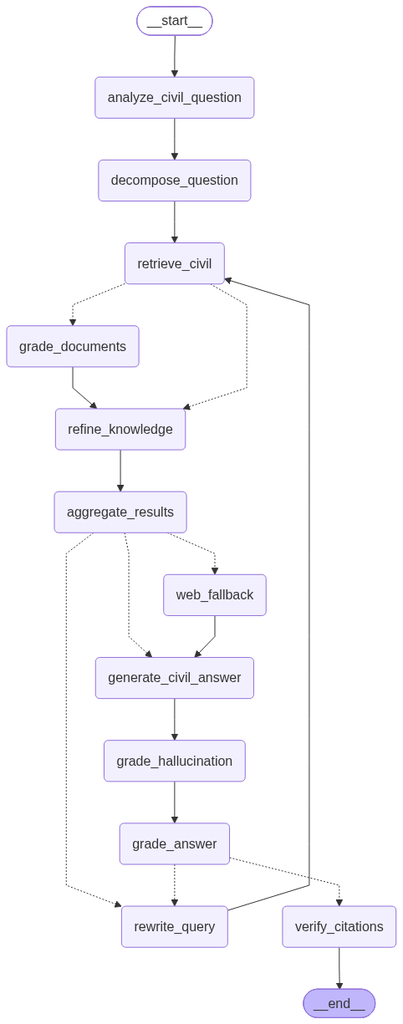

```python
# 선행 셀: 5-2, 5-3 (노드 함수 12종 + 라우터)
from langgraph.graph import StateGraph, START, END

civil_workflow = StateGraph(CivilRagState)

# 노드 등록 — 노드명은 명세, 함수명은 civil_ 접두어 (기존 노트북 함수와 충돌 방지)
civil_workflow.add_node("analyze_civil_question", analyze_civil_question)
civil_workflow.add_node("decompose_question", decompose_question)
civil_workflow.add_node("retrieve_civil", retrieve_civil)
civil_workflow.add_node("grade_documents", grade_civil_document)
civil_workflow.add_node("refine_knowledge", civil_refine_knowledge)
civil_workflow.add_node("aggregate_results", aggregate_civil_results)
civil_workflow.add_node("rewrite_query", civil_rewrite_query)
civil_workflow.add_node("web_fallback", civil_web_fallback)
civil_workflow.add_node("generate_civil_answer", generate_civil_answer)
civil_workflow.add_node("grade_hallucination", civil_grade_hallucination)
civil_workflow.add_node("grade_answer", civil_grade_answer)
civil_workflow.add_node("verify_citations", civil_verify_citations)

# 엣지 구성
civil_workflow.add_edge(START, "analyze_civil_question")
civil_workflow.add_edge("analyze_civil_question", "decompose_question")
civil_workflow.add_edge("decompose_question", "retrieve_civil")

# Send 병렬 문서 평가 (검색 결과가 없으면 refine 으로 직행)
civil_workflow.add_conditional_edges(
    "retrieve_civil", create_civil_grade_workers, ["grade_documents", "refine_knowledge"]
)
civil_workflow.add_edge("grade_documents", "refine_knowledge")
civil_workflow.add_edge("refine_knowledge", "aggregate_results")

civil_workflow.add_conditional_edges(
    "aggregate_results", route_after_aggregate,
    {"rewrite_query": "rewrite_query", "web_fallback": "web_fallback",
     "generate_civil_answer": "generate_civil_answer"},
)
civil_workflow.add_edge("rewrite_query", "retrieve_civil")
civil_workflow.add_edge("web_fallback", "generate_civil_answer")
civil_workflow.add_edge("generate_civil_answer", "grade_hallucination")
civil_workflow.add_edge("grade_hallucination", "grade_answer")

civil_workflow.add_conditional_edges(
    "grade_answer", route_after_grade,
    {"rewrite_query": "rewrite_query", "verify_citations": "verify_citations"},
)
civil_workflow.add_edge("verify_citations", END)

# 그래프 컴파일
civil_law_agent = civil_workflow.compile()

# 그래프 시각화 (PNG 실패 시 mermaid 텍스트로 폴백)
try:
    from IPython.display import Image, display
    display(Image(civil_law_agent.get_graph().draw_mermaid_png(max_retries=5, retry_delay=2.0)))
except Exception as e:
    print(f"PNG 시각화 생략({e}) — mermaid 텍스트 출력:")
    print(civil_law_agent.get_graph().draw_mermaid())
```

## [실습 구현] 5-5. 민법 RAG 에이전트 테스트 (2건)

테스트 질의 2건을 실행하여 답변(조항 인용 포함)과 노드별 trace, 평가 점수를 확인합니다.

```python
# 선행 셀: 5-4 (civil_law_agent)
civil_test_questions_step5 = [
    "이혼할 때 재산분할은 언제까지 청구할 수 있고, 위자료 청구와는 어떻게 다른가요?",
    "미성년자가 부모 동의 없이 고가의 스마트폰 할부 계약을 했다면 취소할 수 있나요?",
]

for tq in civil_test_questions_step5:
    print("=" * 100)
    print(f"질문: {tq}")
    print("=" * 100)
    result = civil_law_agent.invoke(
        {"question": tq},
        config={"recursion_limit": 50, "configurable": {"retriever": "rerank"}},
    )

    print("\n[답변]")
    print(result["node_answer"])
    print("\n[평가] 환각(1=근거충실): {:.2f} / 답변점수: {:.2f} / 인용검증: {:.0%} ({}개)".format(
        result.get("hallucination_score", -1),
        result.get("answer_score", -1),
        result.get("citation_valid_ratio", 0),
        len(result.get("citations", [])),
    ))
    print("\n[trace] 노드별 실행 로그")
    for t in result.get("trace", []):
        print(f"  {t['node']:24s} {t['elapsed']:7.2f}s  out={t['out_summary']}")
```

```
====================================================================================================
질문: 이혼할 때 재산분할은 언제까지 청구할 수 있고, 위자료 청구와는 어떻게 다른가요?
====================================================================================================
---민법 질문 유형 분석---
  분류: 친족 (필터: 제4편 친족)
---민법 질문 분해---
  하위 질문 2개: ['이혼 시 재산분할 청구권의 소멸시효 기간은 어떻게 되는가?', '재산분할 청구권과 위자료 청구권의 법적 성격 및 청구 요건은 무엇인가?']
---민법 검색(rerank, filter=제4편 친족): 8개 문서---
  [관련 X] 제836조의2
  [관련 O] 제839조의2 (0.90)
  [관련 O] 제839조의3 (0.70)
  [관련 X] 제829조
  [관련 X] 제842조
  [관련 X] 제907조
  [관련 X] 제906조
  [관련 X] 제841조
---민법 지식 정제: 관련 문서 2개---
  고품질 정보 3개 추출 (전체 답변 가능성: 0.80)
---민법 정보 집계: 총 3개 조각---
  query_relevance: 0.93
---민법 답변 생성---
---민법 환각 평가---
  환각 점수(1=근거 충실): 0.60 — 답변은 근거 자료에 명시된 재산분할청구권의 소멸시효(이혼한 날부터 2년)와 협의상 이혼한 자가 재산분할을 청구할 수 있다는 점, 협의가 되지 않을 경우 가정법원이 분할의 액수와 방법을 정한다는 내용을 충실히 반영하고 있습니다. 그러나 답변에서 위자료 청구에 관한 내용과 그 소멸시효에 대해 언급한 부분은 근거 자료에 포함되어 있지 않아 추가적인 정보가 포함된 것으로 판단됩니다. 따라서 근거 자료에 기반한 내용과 그렇지 않은 내용이 혼재되어 있어 완전한 충실도는 아니라고 평가합니다.
---민법 답변 품질 평가---
  답변 점수: 0.95 — 답변은 이혼 시 재산분할 청구권의 행사 기간(이혼한 날부터 2년 이내)과 소멸시효에 대해 명확히 설명하고 있으며, 위자료 청구와 재산분할 청구의 차이점(정신적 손해 배상과 재산 분할 권리의 차이)을 구체적으로 구분하여 설명하고 있습니다. 또한 관련 법조항(민법 제839조의2)을 인용하고, 협의 불성립 시 가정법원의 역할과 주의사항도 상세히 안내하여 질문에 대한 완전한 답변을 제공하고 있습니다. 다만, 위자료 청구의 소멸시효 기간에 대한 구체적인 기간 언급이 없어 약간의 보완 여지가 있으나, 전반적으로 매…
---민법 인용 조항 검증---
  제839조의2: DB O*
  인용 1개 중 1개 검증 통과 (ratio=1.0)

[답변]
## 요약
이혼할 때 재산분할청구권은 이혼한 날부터 2년 이내에 행사해야 하며, 이 기간이 지나면 소멸합니다(민법 제839조의2). 위자료 청구는 정신적 손해에 대한 배상을 요구하는 것이고, 재산분할은 혼인 중 형성된 재산을 나누는 권리로서 목적과 성격이 다릅니다.

## 상세 설명
재산분할청구권은 협의상 이혼한 경우 일방이 다른 일방에게 혼인 기간 동안 공동으로 형성한 재산을 분할해 달라고 요구할 수 있는 권리입니다(민법 제839조의2). 만약 협의가 이루어지지 않거나 협의가 불가능한 경우, 가정법원이 당사자의 청구에 따라 분할의 액수와 방법을 정하게 됩니다. 이 권리는 이혼한 날부터 2년이 지나면 소멸하여 더 이상 청구할 수 없습니다.

반면, 위자료 청구는 이혼 과정에서 상대방의 불법행위나 부당한 행위로 인해 입은 정신적 고통에 대한 배상을 요구하는 것으로, 재산분할과는 별개의 권리입니다. 위자료 청구에는 별도의 소멸시효가 적용되며, 재산분할청구권과 달리 이혼 후에도 일정 기간 내에 청구할 수 있습니다.

## 관련 조항
- 민법 제839조의2(재산분할청구권): 협의상 이혼한 자는 상대방에게 재산분할을 청구할 수 있고, 협의가 되지 않으면 가정법원이 분할의 액수와 방법을 정함. 재산분할청구권은 이혼한 날부터 2년이 지나면 소멸함.
```

[output cut: 86 more lines]

```
  retrieve_civil             11.15s  out={'documents': 8}
  grade_documents             0.74s  out={'graded_docs': 1}
  grade_documents             0.87s  out={'graded_docs': 1}
  grade_documents             0.73s  out={'graded_docs': 0}
  grade_documents             0.73s  out={'graded_docs': 1}
  grade_documents             1.00s  out={'graded_docs': 1}
  grade_documents             0.77s  out={'graded_docs': 0}
  grade_documents             0.70s  out={'graded_docs': 1}
  grade_documents             0.74s  out={'graded_docs': 0}
  refine_knowledge            4.49s  out={'extracted_info': 5}
  aggregate_results           0.00s  out={'processed_info': 5, 'query_relevance': 0.89}
  generate_civil_answer       6.71s  out={'node_answer': '## 요약\n미성년자가 부모(법정대리인)의 동의 없이 고가의 스마트폰 할부 계약을 체결한 경우, 원칙적으로 그', 'generation': '## 요약\n미성년자가 부모(법정대리인)의 동의 없이 고가의 스마트폰 할부 계약을 체결한 경우, 원칙적으로 그', 'num_generations': 1}
  grade_hallucination         2.45s  out={'hallucination_score': 0.95}
  grade_answer                2.26s  out={'answer_score': 0.95}
  verify_citations            0.01s  out={'citations': 4, 'citation_valid_ratio': 1.0}
```

## [실습 구현] 6-1. 노드 레지스트리 (`NODE_REGISTRY` + `@register_node`)

노드를 레지스트리로 관리하여 조합/파라미터를 바꿔가며 A/B 실험이 가능하게 합니다. STEP 5 에서 정의한 노드 함수(이미 `traced` 래퍼 적용됨)를 데코레이터 호출 방식으로 등록합니다. `optional=False` 인 노드(검색/집계/생성)는 어떤 실험 조합에서도 항상 포함됩니다.

```python
# 선행 셀: 5-2, 5-3 (민법 노드 함수 12종)
from typing import Dict

NODE_REGISTRY: Dict[str, dict] = {}


def register_node(name, group, desc, optional=True):
    """노드 함수를 NODE_REGISTRY 에 등록하는 데코레이터.

    모든 노드는 (state, config) -> dict 시그니처를 지키며,
    trace 자동 기록은 STEP 5 의 traced 래퍼가 담당합니다.
    """
    def decorator(fn):
        NODE_REGISTRY[name] = {"fn": fn, "group": group, "desc": desc, "optional": optional}
        return fn
    return decorator


# ── STEP 5 노드 등록 ──
register_node("analyze_civil_question", "preprocess", "질문 유형 분류(편) + 메타데이터 필터", True)(analyze_civil_question)
register_node("decompose_question", "preprocess", "복합 질문을 하위 질문으로 분해", True)(decompose_question)

# 리트리버 변형 3종 — 동일 함수, config 로 전환 (build 시 retriever 파라미터가 결정)
register_node("retrieve_basic", "retrieval", "기본 유사도 검색 (k=top_k)", False)(retrieve_civil)
register_node("retrieve_mmr", "retrieval", "MMR 다양성 검색", False)(retrieve_civil)
register_node("retrieve_rerank", "retrieval", "CrossEncoder Re-rank 검색", False)(retrieve_civil)

register_node("grade_documents", "grading", "Send 병렬 문서 관련성 평가 (CRAG)", True)(grade_civil_document)
register_node("refine_knowledge", "grading", "InformationStrip 지식 정제 (CRAG)", True)(civil_refine_knowledge)
register_node("aggregate_results", "grading", "Map 결과 병합 + 관련성 산출", False)(aggregate_civil_results)

register_node("rewrite_query", "correction", "쿼리 재작성 (Self-RAG)", True)(civil_rewrite_query)
register_node("web_fallback", "correction", "웹 검색 폴백 (CRAG)", True)(civil_web_fallback)

register_node("generate_civil_answer", "generation", "구조화 답변 생성", False)(generate_civil_answer)

register_node("grade_hallucination", "evaluation", "환각 평가 (Self-RAG)", True)(civil_grade_hallucination)
register_node("grade_answer", "evaluation", "답변 품질 평가 (Self-RAG)", True)(civil_grade_answer)
register_node("verify_citations", "evaluation", "인용 조항 자동 검증", True)(civil_verify_citations)

# on/off 가능한 노드 목록 (실험 조합의 축)
ALL_OPTIONAL_NODES = [n for n, v in NODE_REGISTRY.items() if v["optional"]]

print(f"NODE_REGISTRY: {len(NODE_REGISTRY)}개 노드 등록")
for name, info in NODE_REGISTRY.items():
    print(f"  [{info['group']:10s}] {name:24s} optional={info['optional']} — {info['desc']}")
```

```
NODE_REGISTRY: 14개 노드 등록
  [preprocess] analyze_civil_question   optional=True — 질문 유형 분류(편) + 메타데이터 필터
  [preprocess] decompose_question       optional=True — 복합 질문을 하위 질문으로 분해
  [retrieval ] retrieve_basic           optional=False — 기본 유사도 검색 (k=top_k)
  [retrieval ] retrieve_mmr             optional=False — MMR 다양성 검색
  [retrieval ] retrieve_rerank          optional=False — CrossEncoder Re-rank 검색
  [grading   ] grade_documents          optional=True — Send 병렬 문서 관련성 평가 (CRAG)
  [grading   ] refine_knowledge         optional=True — InformationStrip 지식 정제 (CRAG)
  [grading   ] aggregate_results        optional=False — Map 결과 병합 + 관련성 산출
  [correction] rewrite_query            optional=True — 쿼리 재작성 (Self-RAG)
  [correction] web_fallback             optional=True — 웹 검색 폴백 (CRAG)
  [generation] generate_civil_answer    optional=False — 구조화 답변 생성
  [evaluation] grade_hallucination      optional=True — 환각 평가 (Self-RAG)
  [evaluation] grade_answer             optional=True — 답변 품질 평가 (Self-RAG)
  [evaluation] verify_citations         optional=True — 인용 조항 자동 검증
```

## [실습 구현] 6-2. 실험 설정 (`ExperimentConfig`) + 동적 그래프 빌더 (`build_civil_graph`)

`enabled_nodes` 에 따라 노드/엣지를 동적으로 구성합니다. optional 노드가 꺼지면 **글루(어댑터) 노드**로 앞뒤를 자동으로 이어붙여 그래프가 깨지지 않게 합니다:

- `grade_documents` off → `docs_passthrough` 가 documents 를 graded_docs 로 그대로 전달
- `refine_knowledge` off → `docs_to_info` 가 문서를 LLM 호출 없이 InformationStrip 으로 변환
- `rewrite_query`/`web_fallback` off → 라우터가 남은 경로로 자동 연결

```python
# 선행 셀: 6-1 (NODE_REGISTRY)
from dataclasses import dataclass, field
from typing import List, Literal

from langgraph.graph import StateGraph, START, END
from langgraph.types import Send


@dataclass
class ExperimentConfig:
    """민법 RAG 실험 설정 — 노드 조합/리트리버/임계값/프롬프트 변형을 전환"""
    name: str
    retriever: Literal["basic", "mmr", "rerank"] = "rerank"
    top_k: int = 5
    enabled_nodes: List[str] = field(default_factory=lambda: list(ALL_OPTIONAL_NODES))
    llm_model: str = "gpt-4.1-mini"
    temperature: float = 0.0
    max_rewrites: int = 2
    relevance_threshold: float = 0.6
    answer_threshold: float = 0.7
    prompt_variant: Literal["basic", "structured", "citation_heavy"] = "structured"

    def to_runnable_config(self):
        """LangGraph invoke 용 config 변환 (기본 모델이면 전역 llm 재사용)"""
        return {
            "recursion_limit": 60,
            "configurable": {
                "retriever": self.retriever,
                "top_k": self.top_k,
                "llm_model": None if (self.llm_model == "gpt-4.1-mini" and self.temperature == 0.0) else self.llm_model,
                "temperature": self.temperature,
                "max_rewrites": self.max_rewrites,
                "relevance_threshold": self.relevance_threshold,
                "answer_threshold": self.answer_threshold,
                "prompt_variant": self.prompt_variant,
            },
        }


# ── 글루(어댑터) 노드: optional 노드가 꺼져도 그래프가 깨지지 않게 연결 ──
@traced("docs_passthrough")
def _civil_docs_passthrough(state: CivilRagState, config=None):
    """grade_documents 가 꺼진 경우: documents 를 평가 없이 graded_docs 로 전달"""
    return {"graded_docs": state.get("documents", [])}


@traced("docs_to_info")
def _civil_docs_to_info(state: CivilRagState, config=None):
    """refine_knowledge 가 꺼진 경우: 문서를 LLM 호출 없이 InformationStrip 으로 변환"""
    docs = state.get("graded_docs") or state.get("documents", [])
    unique, seen = [], set()
    for d in docs:
        key = (d.metadata.get("article_no"), d.metadata.get("chunk_index"))
        if key not in seen:
            seen.add(key)
            unique.append(d)
    strips = [
        InformationStrip(
            content=d.page_content[:1500],
            source=f"{d.metadata.get('name', '민법')} {d.metadata.get('article_no', '')}".strip(),
            relevance_score=float(d.metadata.get("relevance_score", 0.75)),
            faithfulness_score=0.75,
        )
        for d in unique[:10]
    ]
    return {"extracted_info": strips}


def _make_grade_workers(fallback_node):
    """검색 결과 → grade_documents 병렬 워커 생성 (결과 없으면 fallback 으로)"""
    def _workers(state: CivilRagState):
        if not state["documents"]:
            return fallback_node
        question = state.get("rewritten_query") or state["question"]
        return [
            Send("grade_documents", {
                "document": doc.page_content,
                "doc_metadata": doc.metadata,
                "question": question,
            })
            for doc in state["documents"]
        ]
    return _workers


def build_civil_graph(config: ExperimentConfig):
    """ExperimentConfig 에 따라 민법 RAG 그래프를 동적으로 구성/컴파일"""
    enabled = set(config.enabled_nodes) & set(ALL_OPTIONAL_NODES)
    g = StateGraph(CivilRagState)

    # ── 필수 노드 ──
    g.add_node("retrieve_civil", retrieve_civil)
    g.add_node("aggregate_results", aggregate_civil_results)
    g.add_node("generate_civil_answer", generate_civil_answer)

    # ── 전처리 체인: START → (analyze) → (decompose) → retrieve ──
    pre_chain = [n for n in ["analyze_civil_question", "decompose_question"] if n in enabled]
    for n in pre_chain:
        g.add_node(n, NODE_REGISTRY[n]["fn"])
    chain = [START] + pre_chain + ["retrieve_civil"]
    for a, b in zip(chain, chain[1:]):
        g.add_edge(a, b)

    # ── 평가/정제 체인: retrieve → (grade∥) → (refine | docs_to_info) → aggregate ──
    use_grade = "grade_documents" in enabled
    use_refine = "refine_knowledge" in enabled

    if use_refine:
        g.add_node("refine_knowledge", NODE_REGISTRY["refine_knowledge"]["fn"])
        after_docs = "refine_knowledge"
    else:
        g.add_node("docs_to_info", _civil_docs_to_info)
        after_docs = "docs_to_info"

    if use_grade:
        g.add_node("grade_documents", NODE_REGISTRY["grade_documents"]["fn"])
        g.add_conditional_edges("retrieve_civil", _make_grade_workers(after_docs),
                                ["grade_documents", after_docs])
        g.add_edge("grade_documents", after_docs)
    elif use_refine:
        # 평가 없이 정제만 하는 경우: documents 를 graded_docs 로 넘기는 글루 노드
        g.add_node("docs_passthrough", _civil_docs_passthrough)
        g.add_edge("retrieve_civil", "docs_passthrough")
        g.add_edge("docs_passthrough", after_docs)
    else:
        g.add_edge("retrieve_civil", after_docs)
    g.add_edge(after_docs, "aggregate_results")

    # ── 교정 분기: aggregate → rewrite / web_fallback / generate ──
    use_rewrite = "rewrite_query" in enabled
    use_web = "web_fallback" in enabled
    if use_rewrite:
        g.add_node("rewrite_query", NODE_REGISTRY["rewrite_query"]["fn"])
        g.add_edge("rewrite_query", "retrieve_civil")
    if use_web:
        g.add_node("web_fallback", NODE_REGISTRY["web_fallback"]["fn"])
        g.add_edge("web_fallback", "generate_civil_answer")

    def route_aggregate(state, config_rt=None):
        if state.get("query_relevance", 0.0) < config.relevance_threshold:
            if use_rewrite and state.get("num_rewrites", 0) < config.max_rewrites:
                return "rewrite_query"
            if use_web and not state.get("web_docs"):
                return "web_fallback"
        return "generate_civil_answer"

    agg_map = {"generate_civil_answer": "generate_civil_answer"}
    if use_rewrite:
        agg_map["rewrite_query"] = "rewrite_query"
    if use_web:
        agg_map["web_fallback"] = "web_fallback"
    g.add_conditional_edges("aggregate_results", route_aggregate, agg_map)

    # ── 평가 체인: generate → (grade_hallucination) → (grade_answer ⟲) → (verify_citations) → END ──
    eval_chain = [n for n in ["grade_hallucination", "grade_answer", "verify_citations"] if n in enabled]
    for n in eval_chain:
        g.add_node(n, NODE_REGISTRY[n]["fn"])

    def _make_route_grade(next_node):
        """grade_answer 점수 미달 시 재작성 루프, 아니면 다음 노드로"""
        def route_grade(state, config_rt=None):
            if state.get("answer_score", 0.0) < config.answer_threshold and state.get("num_generations", 0) < 3:
                return "rewrite_query"
            return "next"
        return route_grade, {"rewrite_query": "rewrite_query", "next": next_node}

    seq = ["generate_civil_answer"] + eval_chain + [END]
    for a, b in zip(seq, seq[1:]):
        if a == "grade_answer" and use_rewrite:
            router, path_map = _make_route_grade(b)
            g.add_conditional_edges("grade_answer", router, path_map)
        else:
            g.add_edge(a, b)

    compiled = g.compile()
    compiled.get_graph()  # 그래프 유효성 검사 (구성 오류 시 예외 발생)
    return compiled


# 스모크 테스트: 프리셋 구성이 모두 유효한 그래프로 컴파일되는지 확인
_smoke = ExperimentConfig(name="_smoke", enabled_nodes=[])
print("minimal 구성 노드:", list(build_civil_graph(_smoke).get_graph().nodes.keys()))
_smoke_full = ExperimentConfig(name="_smoke_full")
print("full 구성 노드:", list(build_civil_graph(_smoke_full).get_graph().nodes.keys()))
```

```
minimal 구성 노드: ['__start__', 'retrieve_civil', 'aggregate_results', 'generate_civil_answer', 'docs_to_info', '__end__']
full 구성 노드: ['__start__', 'retrieve_civil', 'aggregate_results', 'generate_civil_answer', 'analyze_civil_question', 'decompose_question', 'refine_knowledge', 'grade_documents', 'rewrite_query', 'web_fallback', 'grade_hallucination', 'grade_answer', 'verify_citations', '__end__']
```

## [실습 구현] 6-3. 실험 러너 (`run_experiment`) + 비교 리포트 (`compare_experiments`)

- 각 (config, question) 조합을 실행하고 지표를 수집합니다: 답변, 전체/노드별 소요시간, LLM 호출 수, 토큰/비용, 검색 문서 수, hallucination/answer 점수, 인용 검증 비율, 재시도 횟수
- 결과는 `experiments/results_{timestamp}.csv` / `.json` 으로 저장하고, 실패한 실행은 `error` 컬럼에 기록 후 계속 진행합니다.
- `compare_experiments` 는 config 별 평균 지표 표 + 히트맵/막대그래프(`experiments/report_{timestamp}.png`)를 생성합니다.

```python
# 선행 셀: 6-2 (ExperimentConfig, build_civil_graph)
import json as _json
import os as _os
import time
from datetime import datetime

import matplotlib
import matplotlib.pyplot as plt
import pandas as pd
from langchain_community.callbacks import get_openai_callback

# 한글 폰트 설정 (Windows: Malgun Gothic)
try:
    matplotlib.rcParams["font.family"] = "Malgun Gothic"
    matplotlib.rcParams["axes.unicode_minus"] = False
except Exception:
    pass

EXPERIMENT_DIR = "experiments"


def estimate_llm_calls(config: ExperimentConfig, n_questions: int) -> int:
    """실행 전 예상 LLM 호출 수 (재작성 루프 제외한 1회 통과 기준)"""
    enabled = set(config.enabled_nodes)
    per_run = 1  # generate
    per_run += len(enabled & {"analyze_civil_question", "decompose_question",
                              "refine_knowledge", "grade_hallucination", "grade_answer"})
    if "grade_documents" in enabled:
        per_run += 8  # 병렬 문서 평가 상한
    return per_run * n_questions


def run_experiment(configs, questions) -> pd.DataFrame:
    """각 (config, question) 조합을 실행하고 지표를 수집하여 DataFrame 으로 반환"""
    _os.makedirs(EXPERIMENT_DIR, exist_ok=True)
    rows = []

    for cfg in configs:
        try:
            graph = build_civil_graph(cfg)
        except Exception as e:
            rows.append({"config": cfg.name, "question": "-", "error": f"그래프 빌드 실패: {e}"})
            continue

        for q in questions:
            row = {"config": cfg.name, "question": q, "error": ""}
            t0 = time.perf_counter()
            try:
                with get_openai_callback() as cb:
                    result = graph.invoke({"question": q}, config=cfg.to_runnable_config())
                row.update({
                    "answer": result.get("node_answer", ""),
                    "elapsed_s": round(time.perf_counter() - t0, 2),
                    "llm_calls": cb.successful_requests,
                    "total_tokens": cb.total_tokens,
                    "cost_usd": round(cb.total_cost, 5),
                    "num_docs": len(result.get("documents", [])),
                    "hallucination_score": result.get("hallucination_score"),
                    "answer_score": result.get("answer_score"),
                    "citation_valid_ratio": result.get("citation_valid_ratio"),
                    "num_rewrites": result.get("num_rewrites", 0),
                    "node_times": {t["node"]: t["elapsed"] for t in result.get("trace", [])},
                })
            except Exception as e:
                # 실패한 실행은 error 에 기록하고 계속 진행
                row["error"] = str(e)[:200]
                row["elapsed_s"] = round(time.perf_counter() - t0, 2)
            rows.append(row)
            print(f"  [{cfg.name:10s}] {q[:28]}… → {row.get('elapsed_s', '?')}s "
                  f"(오류: {row['error'] or '없음'})")

    df = pd.DataFrame(rows)
    ts = datetime.now().strftime("%Y%m%d_%H%M%S")
    csv_path = f"{EXPERIMENT_DIR}/results_{ts}.csv"
    df.drop(columns=["node_times"], errors="ignore").to_csv(csv_path, index=False, encoding="utf-8-sig")
    with open(f"{EXPERIMENT_DIR}/results_{ts}.json", "w", encoding="utf-8") as f:
        _json.dump(rows, f, ensure_ascii=False, indent=1, default=str)
    print(f"\n결과 저장: {csv_path} / .json")
    return df


def compare_experiments(df: pd.DataFrame) -> pd.DataFrame:
    """config 별 평균 지표 표 + 최고 성능 하이라이트 + 히트맵/막대그래프 저장"""
    ok = df[df["error"] == ""].copy()
    if ok.empty:
        print("성공한 실행이 없습니다.")
        return pd.DataFrame()

    metrics = ["answer_score", "hallucination_score", "citation_valid_ratio",
               "elapsed_s", "llm_calls", "total_tokens", "cost_usd", "num_rewrites"]
    summary = ok.groupby("config")[metrics].mean().round(3)
    print(summary.to_string())

    # 품질 종합(3개 품질 지표 평균) 1위 하이라이트
    quality = summary[["answer_score", "hallucination_score", "citation_valid_ratio"]].mean(axis=1)
    best = quality.idxmax()
    print(f"\n★ 품질 종합 1위: {best} (품질 {quality.max():.3f}, "
          f"평균 {summary.loc[best, 'elapsed_s']:.1f}s, {summary.loc[best, 'llm_calls']:.1f}회 호출)")

    # 시각화: (config × 품질지표) 히트맵 + 소요시간/호출수 막대그래프
    fig, axes = plt.subplots(1, 3, figsize=(16, 4.5))

    qcols = ["answer_score", "hallucination_score", "citation_valid_ratio"]
    im = axes[0].imshow(summary[qcols].values, cmap="YlGn", vmin=0, vmax=1, aspect="auto")
    axes[0].set_xticks(range(len(qcols)), ["답변점수", "환각(근거)", "인용검증"], rotation=15)
    axes[0].set_yticks(range(len(summary)), summary.index)
    for i in range(len(summary)):
        for j, c in enumerate(qcols):
            axes[0].text(j, i, f"{summary.iloc[i][c]:.2f}", ha="center", va="center", fontsize=9)
    axes[0].set_title("품질 지표 히트맵")
    fig.colorbar(im, ax=axes[0], shrink=0.8)

    summary["elapsed_s"].plot.bar(ax=axes[1], color="#4C72B0")
    axes[1].set_title("평균 소요시간 (s)")
    axes[1].tick_params(axis="x", rotation=20)

    summary[["llm_calls", "cost_usd"]].plot.bar(ax=axes[2], secondary_y="cost_usd", color=["#DD8452", "#55A868"])
    axes[2].set_title("LLM 호출 수 / 비용($)")
    axes[2].tick_params(axis="x", rotation=20)

    plt.tight_layout()
    ts = datetime.now().strftime("%Y%m%d_%H%M%S")
    png_path = f"{EXPERIMENT_DIR}/report_{ts}.png"
    plt.savefig(png_path, dpi=110, bbox_inches="tight")
    plt.show()
    print(f"리포트 저장: {png_path}")
    return summary


print("run_experiment / compare_experiments 정의 완료")
```

```
run_experiment / compare_experiments 정의 완료
```

## [실습 구현] 6-4. 기본 프리셋 5종 정의 및 비교 실행

| 프리셋 | 구성 |
| --- | --- |
| `minimal` | 검색 + 생성만 (optional 전부 off) |
| `self_rag` | + 3종 grader(문서/환각/답변) + 쿼리 재작성 |
| `crag` | + 문서평가 + 지식정제 + 웹 폴백 |
| `full` | 전체 노드 on |
| `fast` | basic 리트리버 + optional 전부 off |

테스트 질의 5개 × 프리셋 5종 = 25회 실행. **비용이 크므로 실행 전에 예상 LLM 호출 수를 출력하고 확인 후 실행하세요.**

```
  minimal   : 예상   5회 (질의당 1회)
  self_rag  : 예상  55회 (질의당 11회)
  crag      : 예상  50회 (질의당 10회)
  full      : 예상  70회 (질의당 14회)
  fast      : 예상   5회 (질의당 1회)
총 예상 LLM 호출: 약 185회 (gpt-4.1-mini) — 재작성 루프 발생 시 최대 2배까지 증가 가능
---민법 검색(rerank, filter=None): 5개 문서---
---민법 정보 집계: 총 5개 조각---
  query_relevance: 0.75
---민법 답변 생성---
  [minimal   ] 이혼 시 재산분할 청구권은 언제까지 행사할 수 있나… → 13.85s (오류: 없음)
---민법 검색(rerank, filter=None): 5개 문서---
---민법 정보 집계: 총 5개 조각---
  query_relevance: 0.75
---민법 답변 생성---
  [minimal   ] 미성년자가 법정대리인 동의 없이 한 계약은 취소할 … → 14.35s (오류: 없음)
---민법 검색(rerank, filter=None): 5개 문서---
---민법 정보 집계: 총 5개 조각---
  query_relevance: 0.75
---민법 답변 생성---
  [minimal   ] 전세권과 임차권의 차이는 무엇인가요?… → 13.03s (오류: 없음)
---민법 검색(rerank, filter=None): 5개 문서---
---민법 정보 집계: 총 5개 조각---
  query_relevance: 0.75
---민법 답변 생성---
  [minimal   ] 타인의 물건을 선의취득하려면 어떤 요건이 필요한가요… → 11.22s (오류: 없음)
---민법 검색(rerank, filter=None): 5개 문서---
---민법 정보 집계: 총 5개 조각---
  query_relevance: 0.75
---민법 답변 생성---
  [minimal   ] 유류분 제도란 무엇이고 누가 청구할 수 있나요?… → 11.34s (오류: 없음)
---민법 검색(rerank, filter=None): 5개 문서---
  [관련 X] 제842조
  [관련 X] 제841조
  [관련 X] 제836조의2
  [관련 O] 제839조의2 (1.00)
  [관련 X] 제839조의3
---민법 정보 집계: 총 1개 조각---
  query_relevance: 1.00
---민법 답변 생성---
```

[output cut: 262 more lines]

```
---민법 정보 집계: 총 5개 조각---
  query_relevance: 0.75
---민법 답변 생성---
  [fast      ] 유류분 제도란 무엇이고 누가 청구할 수 있나요?… → 7.4s (오류: 없음)

결과 저장: experiments/results_20260801_160335.csv / .json
          answer_score  hallucination_score  citation_valid_ratio  elapsed_s  llm_calls  total_tokens  cost_usd  num_rewrites
config
crag               NaN                  NaN                   NaN     15.776        7.0        4730.0     0.003           0.0
fast               NaN                  NaN                   NaN      7.122        1.0        1902.6     0.002           0.0
full              0.97                 0.95                   1.0     22.894       11.0        7837.2     0.005           0.0
minimal            NaN                  NaN                   NaN     12.758        1.0        2047.0     0.002           0.0
self_rag          0.95                 0.94                   NaN     17.596        8.0        5884.4     0.003           0.0

★ 품질 종합 1위: full (품질 0.973, 평균 22.9s, 11.0회 호출)
```

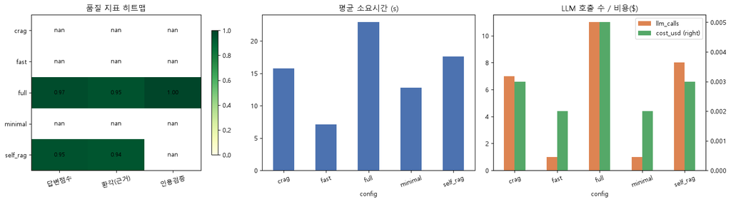

```
리포트 저장: experiments/report_20260801_160335.png
```

```python
# 선행 셀: 6-3 (run_experiment, compare_experiments)
PRESET_CONFIGS = [
    ExperimentConfig(name="minimal", enabled_nodes=[]),
    ExperimentConfig(name="self_rag", enabled_nodes=[
        "grade_documents", "rewrite_query", "grade_hallucination", "grade_answer"]),
    ExperimentConfig(name="crag", enabled_nodes=[
        "grade_documents", "refine_knowledge", "web_fallback"]),
    ExperimentConfig(name="full"),  # 전체 노드 on (기본값)
    ExperimentConfig(name="fast", retriever="basic", enabled_nodes=[]),
]

experiment_questions = [
    "이혼 시 재산분할 청구권은 언제까지 행사할 수 있나요?",
    "미성년자가 법정대리인 동의 없이 한 계약은 취소할 수 있나요?",
    "전세권과 임차권의 차이는 무엇인가요?",
    "타인의 물건을 선의취득하려면 어떤 요건이 필요한가요?",
    "유류분 제도란 무엇이고 누가 청구할 수 있나요?",
]

# 실행 전 예상 LLM 호출 수 출력 (재작성 루프 발생 시 증가할 수 있음)
total_est = 0
for cfg in PRESET_CONFIGS:
    est = estimate_llm_calls(cfg, len(experiment_questions))
    total_est += est
    print(f"  {cfg.name:10s}: 예상 {est:3d}회 (질의당 {est // len(experiment_questions)}회)")
print(f"총 예상 LLM 호출: 약 {total_est}회 (gpt-4.1-mini) — 재작성 루프 발생 시 최대 2배까지 증가 가능")

# 위 예상치를 확인한 후 아래를 실행하세요.
experiment_df = run_experiment(PRESET_CONFIGS, experiment_questions)
experiment_summary = compare_experiments(experiment_df)
```

## [실습 구현] 7-0. 멀티 에이전트 라우팅 상태 + 간이 법률 에이전트 + HITL 보조 노드

원본 노트북 4-2/5-2 절에 해당하는 구성 요소입니다.

- `merge_agent_responses` 커스텀 리듀서 + `ResearchAgentState`
- 개인정보보호법/근로기준법/주택임대차보호법/웹: **간이 에이전트** (검색→생성 1-패스, 원본은 CRAG 서브그래프)
- HITL 보조 노드: `approved_node` / `rejected_node` / `route_after_human_review`

```python
# 선행 셀: 0-3 (llm, 검색 도구), 5-1 (ChatPromptTemplate 은 5-2 에서 임포트됨)
from operator import add
from typing import Annotated

from langchain_core.prompts import ChatPromptTemplate


def merge_agent_responses(left: dict, right: dict) -> dict:
    """에이전트 응답 병합 커스텀 리듀서 (병렬 실행 지원)"""
    if left is None:
        left = {}
    if right is None:
        right = {}
    merged = left.copy()
    merged.update(right)
    return merged


class ResearchAgentState(TypedDict):
    """질문 라우팅 및 다중 에이전트 조합 시스템의 상태 정의"""
    question: str
    answers: Annotated[List[str], add]
    agent_responses: Annotated[dict, merge_agent_responses]
    final_answer: str
    datasources: List[str]
    evaluation_report: Optional[dict]
    iteration_count: Optional[int]
    user_decision: Literal["continue", "stop"]
    user_feedback: Optional[str]


def _lite_law_node(agent_key, law_label, search_tool):
    """간이 법률 에이전트: 검색 → 생성 1-패스 (원본 노트북은 CRAG 서브그래프 사용)"""
    def _node(state):
        print(f"--- {law_label} 간이 에이전트 시작 ---")
        question = state["question"]
        feedback = state.get("user_feedback") or ""
        try:
            docs = search_tool.invoke(question)
            context = "\n\n".join(d.page_content for d in docs[:4])
        except Exception as e:
            context = f"(검색 실패: {e})"
        prompt = ChatPromptTemplate.from_messages([
            ("system", f"당신은 {law_label} 전문가입니다. 주어진 법률 조항을 근거로 질문에 답하세요. "
                       "관련 조항 번호를 반드시 인용하고, 근거가 없으면 그 한계를 밝히세요."),
            ("human", "<질문>\n{question}\n</질문>\n<법률 조항>\n{context}\n</법률 조항>{feedback}"),
        ])
        answer = llm.invoke(prompt.format(
            question=question, context=context,
            feedback=f"\n<사용자 피드백>\n{feedback}\n</사용자 피드백>" if feedback else "",
        ))
        current = state.get("agent_responses", {}).copy()
        current[agent_key] = answer.content
        return {"answers": [answer.content], "agent_responses": current}
    return _node


personal_rag_node = _lite_law_node("search_personal", "개인정보보호법", personal_law_search)
labor_rag_node = _lite_law_node("search_labor", "근로기준법", labor_law_search)
housing_rag_node = _lite_law_node("search_housing", "주택임대차보호법", housing_law_search)
web_rag_node = _lite_law_node("search_web", "웹 검색", web_search)


def llm_fallback(state):
    """LLM 일반 응답 (평가/HITL 을 거치지 않고 종료)"""
    print("---Fallback 답변---")
    answer = llm.invoke(f"다음 질문에 정확하고 간결하게 답하세요:\n{state['question']}")
    return {"final_answer": answer.content, "answers": [answer.content]}


# HITL 보조 노드 (원본 노트북 5-2 절과 동일)
def route_after_human_review(state) -> Literal["approved", "rejected"]:
    user_decision = state.get("user_decision", "").lower()
    return "approved" if user_decision in ["approved", "approve", "y", "yes"] else "rejected"


def approved_node(state):
    print("✅ 답변이 승인되었습니다!")
    return {"user_decision": "approved", "final_answer": state["final_answer"]}


def rejected_node(state):
    print(f"❌ 답변이 거부되었습니다. 피드백: {state.get('user_feedback', '')}")
    if state.get("iteration_count", 0) >= 3:
        print("최대 반복 횟수에 도달했습니다. 현재 답변으로 진행합니다.")
        return {"final_answer": f"[최대 수정 후 자동 승인] {state['final_answer']}"}
    return {"user_feedback": state.get("user_feedback", ""), "iteration_count": state.get("iteration_count", 0)}


print("라우팅 상태 + 간이 에이전트 + HITL 보조 노드 준비 완료")
```

```
라우팅 상태 + 간이 에이전트 + HITL 보조 노드 준비 완료
```

## [실습 구현] 7-1. 라우터 확장 — `search_civil` 추가

`ToolSelector`/`ToolSelectors` 를 민법 포함 버전으로 재정의하고 라우팅 프롬프트에 민법 설명과 **경계 케이스 규칙**(주택 임대차 → 주임법 우선, 일반 임대차·전세권 → 민법 병행 등)을 명시합니다. `route_datasources_tool_search` 의 유효 소스 집합에도 `search_civil` 을 추가합니다.

```python
# 선행 셀: 0-3 (llm), 5-4 (civil_law_agent)
from textwrap import dedent
from typing import List, Literal
from pydantic import BaseModel, Field
from langchain_core.prompts import ChatPromptTemplate, MessagesPlaceholder


# 라우팅 모델 재정의 — Literal 에 "search_civil" 추가
class ToolSelector(BaseModel):
    """Routes the user question to the most appropriate tool."""
    tool: Literal["search_personal", "search_labor", "search_housing", "search_civil",
                  "search_web", "llm_fallback"] = Field(
        description="Select one of the tools, based on the user's question.",
    )


class ToolSelectors(BaseModel):
    """Select the appropriate tools that are suitable for the user question."""
    tools: List[ToolSelector] = Field(
        description="Select one or more tools, based on the user's question.",
    )


structured_llm_tool_selector = llm.with_structured_output(ToolSelectors)

# 라우팅 시스템 프롬프트 — 민법 설명 + 경계 케이스 규칙 추가
system_v2 = dedent("""You are an AI assistant specializing in routing user questions to the appropriate tools.
Use the following guidelines to select the most suitable tool(s):

## 법률 관련 도구 (Law-specific Tools)
- **search_personal**: 개인정보 보호법의 구체적인 조항, 법적 규정, 의무사항, 처벌 규정 등에 대한 질문
- **search_labor**: 근로기준법의 구체적인 조항, 근로 조건, 임금, 휴가, 해고 등 법적 규정에 대한 질문
- **search_housing**: 주택임대차보호법의 구체적인 조항, 임대차 계약, 보증금, 임차인 권리 등에 대한 질문
- **search_civil**: 민법의 계약, 채권·채무, 소유권·물권, 불법행위, 손해배상,
  가족관계(혼인/이혼/친권), 상속·유언 등에 대한 질문

## 경계 케이스 규칙 (Boundary Rules)
- **주택 임대차** (주거용 건물의 보증금/갱신/대항력): search_housing 을 우선 선택.
  일반 임대차 법리나 전세권(물권)이 함께 걸리면 search_civil 을 병행 선택
- **근로계약과 민법 총칙이 겹치는 경우** (예: 미성년자 근로계약 취소): search_labor 와 search_civil 을 모두 선택
- **개인정보 + 손해배상(불법행위)**: search_personal 우선, 민법상 손해배상 법리가 쟁점이면 search_civil 병행
- **가족/상속 문제**: 다른 특별법에 해당하지 않으므로 search_civil 단독 선택
- 특별법(개인정보보호법/근로기준법/주택임대차보호법)이 우선 적용되는 영역은 특별법 도구를 우선하고,
  일반 법리(계약 성립/무효/취소, 손해배상 원칙 등)가 쟁점일 때 search_civil 을 함께 선택

## 웹 검색 도구 (Web Search Tool)
**search_web**을 사용하는 경우:
- 최신 정보나 실시간 데이터가 필요한 질문 (예: 최근 개정 사항, 최신 판례)
- 현재 뉴스, 트렌드, 최근 사건에 대한 질문
- 법률 관련이지만 구체적인 조항보다는 현실적 적용 사례나 판례가 필요한 경우
- 통계, 시장 데이터, 가격 정보 등 변동하는 정보

## LLM 일반 응답 도구 (LLM Fallback Tool)
**llm_fallback**을 사용하는 경우:
- 개념적/이론적 설명, 창의적 작업, 논리적 추론, 개인적 조언, 일반적 대화
- 질문이 모호하거나 분류하기 어려운 경우

Always choose all of the appropriate tools based on the user's question.
If a question is about a law but doesn't seem to be asking about specific legal provisions, include both the relevant law search tool and the search_web tool.
""")

route_prompt_v2 = ChatPromptTemplate.from_messages([
    ("system", system_v2),
    MessagesPlaceholder("user_feedback"),
    ("human", "{question}"),
])

question_tool_router = route_prompt_v2 | structured_llm_tool_selector


def analyze_question_tool_search_v2(state):
    """질문을 분석하여 적절한 도구들을 선택 (민법 포함)"""
    question = state["question"]
    print(f"도구 선택을 위해 질문 분석 중: {question}")
    user_feedback = state.get("user_feedback", None)

    result = question_tool_router.invoke({
        "question": question,
        "user_feedback": [("system", f"***You SHOULD consider the following user feedback when selecting tools:***\n<User feedback>{user_feedback}</User feedback>")] if user_feedback else []
    })
    datasources = [tool.tool for tool in result.tools]
    print(f"선택된 도구들: {datasources}")
    return {"datasources": datasources, "agent_responses": {}}


def route_datasources_tool_search_v2(state) -> List[str]:
    """선택된 데이터 소스들로 라우팅 (search_civil 포함)"""
    datasources = set(state["datasources"])
    valid_sources = {"search_personal", "search_labor", "search_housing", "search_civil",
                     "search_web", "llm_fallback"}
    if datasources.issubset(valid_sources):
        return list(datasources)
    return ["llm_fallback"]


# 라우팅 확인 (STEP 7 검증 질의 3건)
for _q in [
    "미성년자와 체결한 근로계약은 민법상 취소할 수 있나요?",
    "이혼 시 재산분할 청구권의 행사기간은?",
    "2024년 이후 개정된 민법 조문 중 상속 관련 변경사항은?",
]:
    _r = question_tool_router.invoke({"question": _q, "user_feedback": []})
    print(f"{_q} → {[t.tool for t in _r.tools]}")
```

```
미성년자와 체결한 근로계약은 민법상 취소할 수 있나요? → ['search_labor', 'search_civil']
이혼 시 재산분할 청구권의 행사기간은? → ['search_civil']
2024년 이후 개정된 민법 조문 중 상속 관련 변경사항은? → ['search_civil', 'search_web']
```

## [실습 구현] 7-2. 상태 확장 + `civil_rag_node` + 최종 답변 종합 개선

- `ResearchAgentStateV2`: `node_scores`(에이전트별 점수), `experiment_config`(STEP 6 연동), `feedback_history`(실습 과제 4번) 추가
- `civil_rag_node`: `experiment_config` 가 지정되면 `build_civil_graph` 로 실험 구성 그래프를 빌드해 실행 (캐시)
- `answer_final_v2`: 법률별 섹션 구조화 + 법률 간 상충/중복 정리 + 전체 인용 조항 취합

```python
# 선행 셀: 7-0 (ResearchAgentState, merge_agent_responses), 5-4 (civil_law_agent), 6-2 (build_civil_graph), 7-1
import json as _json7
from operator import add
from typing import Annotated, Optional

from langchain_core.output_parsers import StrOutputParser


class ResearchAgentStateV2(ResearchAgentState):
    """ResearchAgentState 확장 — 민법 통합 + 실험/피드백 연동"""
    node_scores: Annotated[dict, merge_agent_responses]   # 에이전트별 답변 점수
    experiment_config: Optional[dict]                     # STEP 6 ExperimentConfig 연동 (dict)
    feedback_history: Annotated[List[dict], add]          # 피드백 히스토리 (실습 과제 4번)


# ── 민법 전문 에이전트 노드 ──
_civil_graph_cache = {}


def civil_rag_node(state) -> dict:
    """민법 전문 에이전트 (experiment_config 지정 시 실험 구성 그래프로 실행)"""
    print("--- 민법 전문가 에이전트 시작 ---")
    question = state["question"]
    user_feedback = state.get("user_feedback", None)

    exp_conf = state.get("experiment_config") or None
    if exp_conf:
        # STEP 6 실험 config 연동 — 같은 구성은 캐시 재사용
        key = _json7.dumps(exp_conf, sort_keys=True, ensure_ascii=False)
        if key not in _civil_graph_cache:
            _civil_graph_cache[key] = build_civil_graph(ExperimentConfig(**exp_conf))
        graph = _civil_graph_cache[key]
        run_config = ExperimentConfig(**exp_conf).to_runnable_config()
        print(f"  실험 구성 적용: {exp_conf.get('name', '(이름 없음)')}")
    else:
        graph = civil_law_agent
        run_config = {"recursion_limit": 60}

    answer = graph.invoke(
        {"question": question, "user_feedback": user_feedback if user_feedback else None},
        config=run_config,
    )
    response_text = answer.get("node_answer", "답변을 생성할 수 없습니다.")

    current_responses = state.get("agent_responses", {}).copy()
    current_responses["search_civil"] = response_text

    return {
        "answers": [response_text],
        "agent_responses": current_responses,
        # 에이전트별 점수 수집 (Self-RAG 평가 결과)
        "node_scores": {
            "search_civil": {
                "answer_score": answer.get("answer_score"),
                "hallucination_score": answer.get("hallucination_score"),
                "citation_valid_ratio": answer.get("citation_valid_ratio"),
            }
        },
    }


# ── 최종 답변 종합 노드 개선 ──
rag_prompt_v2 = ChatPromptTemplate.from_messages([
    ("system", dedent("""
        당신은 여러 법률 전문 에이전트의 답변을 종합하는 수석 법률 어시스턴트입니다.
        아래 규칙에 따라 마크다운 답변을 작성하세요.

        ## 답변 구조
        1. **## 핵심 답변** — 질문에 대한 직접적이고 명확한 답변 (2~4문장)
        2. **## 법률별 검토** — 에이전트가 2개 이상이면 법률별 하위 섹션(### 민법, ### 근로기준법 등)으로
           각 법률의 관점을 구조화. 에이전트가 1개면 이 섹션은 상세 설명으로 대체
        3. **## 법률 간 관계** — 여러 법률이 관련된 경우, 상충하거나 중복되는 내용을 명시적으로 정리
           (예: "특별법인 주택임대차보호법이 민법에 우선 적용됨"). 단일 법률이면 생략
        4. **## 인용 조항 목록** — 답변 전체에서 인용된 조항을 법률별로 하단에 취합
           (예: "- 민법 제5조, 제140조 / - 근로기준법 제67조")
        5. **## 주의사항** — 기간 제한, 예외, 실무상 유의점

        ## 규칙
        - 각 에이전트 답변의 조항 인용을 보존하고, 근거 조항 번호를 본문에 명시
        - 법률 용어는 괄호로 쉬운 설명 병기
        - 에이전트 답변에 없는 내용을 만들어내지 말 것
        - 웹 검색 결과는 출처(URL)와 함께 "최신 동향" 정보로 활용""").strip()),
    MessagesPlaceholder("user_feedback"),
    ("human", dedent("""
        <Question>
        {question}
        </Question>

        <Agent Responses>
        {agent_responses}
        </Agent Responses>

        위 에이전트 답변들을 종합하여 최종 답변을 작성하세요.""").strip()),
])

agent_labels_v2 = {
    "search_personal": "🔒 개인정보보호법 전문 에이전트",
    "search_labor": "⚖️ 근로기준법 전문 에이전트",
    "search_housing": "🏠 주택임대차보호법 전문 에이전트",
    "search_civil": "📜 민법 전문 에이전트",
    "search_web": "🌐 웹 검색 에이전트",
    "llm_fallback": "🤖 일반 지식 에이전트",
}


def format_agent_responses_v2(agent_responses_dict):
    """에이전트 응답들을 프롬프트에 적합한 형태로 포맷팅 (민법 포함)"""
    if not agent_responses_dict:
        return "에이전트 응답이 없습니다."
    formatted = []
    for agent_type, response in agent_responses_dict.items():
        if response and response.strip():
            label = agent_labels_v2.get(agent_type, f"📋 {agent_type} 에이전트")
            formatted.append(f"{label}:\n{response.strip()}\n")
    return "\n" + "=" * 50 + "\n" + ("\n" + "=" * 50 + "\n").join(formatted) + "\n" + "=" * 50


def answer_final_v2(state) -> dict:
    """최종 답변 생성 — 법률별 섹션 구조화 + 상충/중복 정리 + 인용 조항 취합"""
    print("---최종 답변 생성 (v2)---")
    question = state["question"]
    user_feedback = state.get("user_feedback", None)
    agent_responses = state.get("agent_responses", {})

    if not agent_responses:
        return {"final_answer": "에이전트로부터 답변을 받지 못했습니다.", "question": question}

    print(f"통합할 에이전트 응답: {list(agent_responses.keys())}")
    rag_chain_v2 = rag_prompt_v2 | llm | StrOutputParser()
    generation = rag_chain_v2.invoke({
        "question": question,
        "agent_responses": format_agent_responses_v2(agent_responses),
        "user_feedback": [("system", f"최종 답변을 생성할 때 다음 사용자 피드백을 고려하세요:\n<피드백>{user_feedback}</피드백>")] if user_feedback else [],
    })
    print(f"최종 답변 생성 완료: {generation[:100]}...")
    return {"final_answer": generation, "question": question}
```

## [실습 구현] 7-3. 평가 에이전트 강화 + HITL 확장 + 통합 그래프 조립

- `EvaluationReport`(Pydantic): 정확성/완전성 점수, 환각 감지+증거, 인용 검증+무효 인용 목록, 개선 제안 (실습 과제 3번)
- `answer_reviewer_v2`: `create_agent` 기반 ReAct 평가 에이전트 — **실제 검색 도구(민법 포함)로 인용 조항을 재확인**
- `human_review_node_v2`: 기존 interrupt 패턴 유지 + `feedback_history` 에 (timestamp, question, decision, feedback) 누적
- 통합 그래프 `legal_rag_agent_v2`: search_civil 노드 등록 + `InMemorySaver` 체크포인터 (HITL 중단/재개)

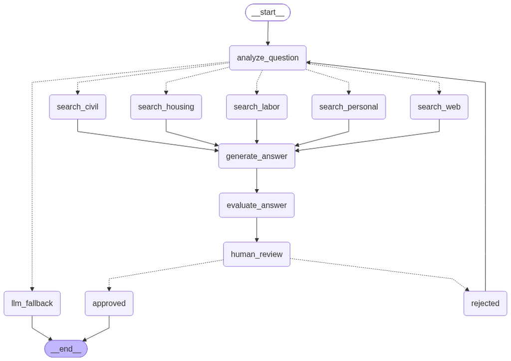

````python
# 선행 셀: 7-0 (HITL 보조 노드), 7-2, 4-3 (tools)
from datetime import datetime

from langchain.agents import create_agent
from langchain_core.messages import HumanMessage
from langgraph.checkpoint.memory import InMemorySaver
from langgraph.graph import StateGraph, START, END
from langgraph.types import interrupt


# ── 강화된 평가 리포트 모델 (실습 과제 3번) ──
class EvaluationReport(BaseModel):
    """답변 평가 리포트 — 정확성/완전성/환각/인용 검증"""
    accuracy_score: float = Field(description="답변의 법적 정확성 (0에서 1 사이)")
    completeness_score: float = Field(description="질문 해결의 완전성 (0에서 1 사이)")
    hallucination_detected: bool = Field(description="근거 없는 내용(환각) 발견 여부")
    hallucination_evidence: List[str] = Field(default_factory=list, description="환각으로 의심되는 문장 목록")
    citation_valid: bool = Field(description="인용된 조항이 모두 실제 법령과 일치하는지")
    invalid_citations: List[str] = Field(default_factory=list, description="검색으로 확인되지 않은 인용 목록")
    improvement_suggestions: List[str] = Field(default_factory=list, description="개선 제안 목록")
    brief_evaluation: str = Field(description="한두 문장의 종합 평가")


evaluation_prompt_v2 = dedent("""
당신은 AI 법률 답변을 검증하는 평가 전문가입니다. 주어진 질문과 답변을 평가하세요.

평가 절차:
1. 답변에 인용된 법률 조항(예: 민법 제839조의2, 근로기준법 제67조)을 **반드시 검색 도구로 재확인**하세요:
   - civil_article_lookup: 민법 조문 번호 직접 조회 (인용 검증에 최우선 사용)
   - civil_law_search / personal_law_search / labor_law_search / housing_law_search: 법률별 내용 검색
   - web_search: 최신 개정 사항 확인
2. 조회한 원문과 답변 내용을 대조하여 환각(근거 없는 서술)을 감지하세요.
3. 아래 JSON 스키마로만 최종 응답하세요 (코드펜스 없이 순수 JSON):

{
  "accuracy_score": 0.0~1.0,
  "completeness_score": 0.0~1.0,
  "hallucination_detected": true/false,
  "hallucination_evidence": ["의심 문장", ...],
  "citation_valid": true/false,
  "invalid_citations": ["확인 안 된 인용", ...],
  "improvement_suggestions": ["제안", ...],
  "brief_evaluation": "한두 문장 종합 평가"
}
""")

# ReAct 평가 에이전트 — 실제 검색 도구로 인용 조항을 재확인
answer_reviewer_v2 = create_agent(
    model=ChatOpenAI(model="gpt-4.1-mini", temperature=0),
    tools=tools,
    system_prompt=evaluation_prompt_v2,
)


def _parse_evaluation_report(content: str) -> EvaluationReport:
    """평가 에이전트 응답을 EvaluationReport 로 파싱 (코드펜스/앞뒤 텍스트 허용)"""
    text = content.strip()
    if "```" in text:
        text = text.split("```")[1].lstrip("json").strip()
    start, end = text.find("{"), text.rfind("}")
    if start > -1 and end > -1:
        text = text[start:end + 1]
    return EvaluationReport.model_validate_json(text)


def evaluate_answer_node_v2(state):
    """강화된 답변 평가 노드 — ReAct 에이전트가 인용 조항을 도구로 재확인"""
    print("---답변 평가 (v2: 인용 재확인 포함)---")
    question = state["question"]
    final_answer = state["final_answer"]

    messages = [HumanMessage(content=f"[질문]\n{question}\n\n[답변]\n{final_answer}")]
    try:
        response = answer_reviewer_v2.invoke({"messages": messages})
        report = _parse_evaluation_report(response["messages"][-1].content)
    except Exception as e:
        print(f"  평가 파싱 실패({e}) — 기본 리포트로 대체")
        report = EvaluationReport(
            accuracy_score=0.5, completeness_score=0.5, hallucination_detected=False,
            citation_valid=True, brief_evaluation=f"평가 실패: {e}",
        )

    report_dict = report.model_dump()
    # 기존 UI(60점 만점) 호환 필드
    report_dict["total_score"] = round((report.accuracy_score + report.completeness_score) / 2 * 60)
    print(f"  정확성 {report.accuracy_score:.2f} / 완전성 {report.completeness_score:.2f} / "
          f"환각 {'감지' if report.hallucination_detected else '없음'} / "
          f"인용 {'유효' if report.citation_valid else '무효: ' + str(report.invalid_citations)}")
    return {"evaluation_report": report_dict, "question": question, "final_answer": final_answer}


def human_review_node_v2(state):
    """interrupt 기반 HITL — 기존 패턴 유지 + feedback_history 누적 (실습 과제 4번)"""
    review_data = {
        "question": state["question"],
        "final_answer": state["final_answer"],
        "evaluation_report": state["evaluation_report"],
        "total_score": state["evaluation_report"].get("total_score", 0),
        "brief_evaluation": state["evaluation_report"].get("brief_evaluation", ""),
        "instruction": "답변을 검토해주세요 (approve/reject):",
    }
    print(f"\n현재 답변: {state['final_answer'][:200]}...")
    print(f"평가: 총점 {review_data['total_score']}/60 — {review_data['brief_evaluation']}")

    user_input = interrupt(value=review_data)

    if isinstance(user_input, dict):
        decision = user_input.get("decision", "").lower()
        feedback = user_input.get("feedback", "")
    elif isinstance(user_input, str):
        if user_input.lower() in ["y", "yes", "approve", "approved", "ok"]:
            decision, feedback = "approved", ""
        else:
            decision = "rejected"
            feedback = user_input if user_input else "답변이 거부되었습니다."
    else:
        decision, feedback = "rejected", "입력이 없어 자동으로 거부되었습니다."

    return {
        "user_decision": decision,
        "user_feedback": feedback,
        "iteration_count": state.get("iteration_count", 0) + 1,
        # 피드백 히스토리 누적 — 다음 라우팅/쿼리 재작성에 user_feedback 으로 반영됨
        "feedback_history": [{
            "timestamp": datetime.now().isoformat(timespec="seconds"),
            "question": state["question"],
            "decision": decision,
            "feedback": feedback,
        }],
    }


# ── 통합 그래프 조립 (민법 포함 + 평가 + HITL) ──
nodes_v2 = {
    "analyze_question": analyze_question_tool_search_v2,
    "search_personal": personal_rag_node,
    "search_labor": labor_rag_node,
    "search_housing": housing_rag_node,
    "search_civil": civil_rag_node,
    "search_web": web_rag_node,
    "generate_answer": answer_final_v2,
    "llm_fallback": llm_fallback,
    "evaluate_answer": evaluate_answer_node_v2,
    "human_review": human_review_node_v2,
    "approved": approved_node,
    "rejected": rejected_node,
}

search_builder_v2 = StateGraph(ResearchAgentStateV2)
for node_name, node_func in nodes_v2.items():
    search_builder_v2.add_node(node_name, node_func)

search_builder_v2.add_edge(START, "analyze_question")
search_builder_v2.add_conditional_edges(
    "analyze_question",
    route_datasources_tool_search_v2,
    ["search_personal", "search_labor", "search_housing", "search_civil", "search_web", "llm_fallback"],
)
for node in ["search_personal", "search_labor", "search_housing", "search_civil", "search_web"]:
    search_builder_v2.add_edge(node, "generate_answer")

search_builder_v2.add_edge("generate_answer", "evaluate_answer")
search_builder_v2.add_edge("evaluate_answer", "human_review")
search_builder_v2.add_conditional_edges(
    "human_review", route_after_human_review,
    {"approved": "approved", "rejected": "rejected"},
)
search_builder_v2.add_edge("approved", END)
search_builder_v2.add_edge("rejected", "analyze_question")  # 거부 시 피드백을 반영해 재실행
search_builder_v2.add_edge("llm_fallback", END)

checkpointer_v2 = InMemorySaver()
legal_rag_agent_v2 = search_builder_v2.compile(checkpointer=checkpointer_v2)

# 그래프 시각화 (PNG 실패 시 mermaid 텍스트)
try:
    from IPython.display import Image, display
    display(Image(legal_rag_agent_v2.get_graph().draw_mermaid_png(max_retries=5, retry_delay=2.0)))
except Exception as e:
    print(f"PNG 시각화 생략({e})")
    print(legal_rag_agent_v2.get_graph().draw_mermaid())
````

## [실습 구현] 7-4. 통합 검증 — 라우팅 3건 + HITL 중단/재개

민법 단독 질의로 전체 파이프라인(검색 → 종합 → 평가 → interrupt → 승인 재개)을 실행합니다. `__interrupt__` 발생 → `Command(resume="y")` 로 재개되는지 확인합니다.

```python
# 선행 셀: 7-3 (legal_rag_agent_v2)
import uuid
from langgraph.types import Command

# ── HITL 중단/재개 검증 (민법 단독 질의) ──
hitl_config = {"configurable": {"thread_id": str(uuid.uuid4())}, "recursion_limit": 80}

hitl_state = {
    "question": "이혼 시 재산분할 청구권의 행사기간은?",
    "answers": [], "agent_responses": {}, "final_answer": "",
    "datasources": [], "evaluation_report": {}, "iteration_count": 0,
    "user_decision": "", "user_feedback": "", "node_scores": {},
    "experiment_config": None, "feedback_history": [],
}

interrupted = False
for chunk in legal_rag_agent_v2.stream(hitl_state, config=hitl_config):
    if "__interrupt__" in chunk:
        interrupted = True
        payload = chunk["__interrupt__"][0].value
        print("\n=== INTERRUPT 발생 ===")
        print(f"평가 총점: {payload['total_score']}/60 — {payload['brief_evaluation']}")
        break

assert interrupted, "HITL interrupt 가 발생하지 않았습니다."

# 승인으로 재개
print("\n=== 'y' (승인) 으로 재개 ===")
resumed = legal_rag_agent_v2.invoke(Command(resume="y"), config=hitl_config)

print("\n[최종 답변]")
print(resumed["final_answer"][:1200])
print("\n[에이전트 점수]", resumed.get("node_scores"))
print("[피드백 히스토리]", resumed.get("feedback_history"))
print("[평가 리포트 요약]", {k: v for k, v in resumed.get("evaluation_report", {}).items()
                          if k in ("accuracy_score", "completeness_score", "hallucination_detected",
                                   "citation_valid", "total_score")})
```

```
도구 선택을 위해 질문 분석 중: 이혼 시 재산분할 청구권의 행사기간은?
선택된 도구들: ['search_civil']
--- 민법 전문가 에이전트 시작 ---
---민법 질문 유형 분석---
  분류: 친족 (필터: 제4편 친족)
---민법 질문 분해---
  하위 질문 0개: []
---민법 검색(rerank, filter=제4편 친족): 5개 문서---
  [관련 X] 제841조
  [관련 X] 제836조의2
  [관련 O] 제839조의2 (0.95)
  [관련 X] 제842조
  [관련 X] 제839조의3
---민법 지식 정제: 관련 문서 1개---
  고품질 정보 3개 추출 (전체 답변 가능성: 1.00)
---민법 정보 집계: 총 3개 조각---
  query_relevance: 0.90
---민법 답변 생성---
---민법 환각 평가---
  환각 점수(1=근거 충실): 0.95 — 답변은 근거 자료에 명시된 내용을 충실히 반영하고 있으며, 재산분할청구권의 소멸시효(2년), 협의상 이혼한 자의 일방이 청구할 수 있다는 점, 협의가 되지 않을 경우 가정법원이 분할의 액수와 방법을 정한다는 점을 정확히 설명하고 있습니다. 다만, 답변에서 민법 조항 번호를 구체적으로 언급한 부분은 근거 자료에 포함되어 있지 않아 약간의 추가 정보가 포함되어 있으나, 이는 일반적으로 알려진 법 조항 번호로서 본문의 근거 내용과 일치합니다. 따라서 전반적으로 근거에 충실한 답변으로 평가됩니다…
---민법 답변 품질 평가---
  답변 점수: 1.00 — 답변은 이혼 시 재산분할 청구권의 행사기간에 대해 명확하게 설명하고 있습니다. 이혼한 날부터 2년 이내에 청구해야 하며, 2년이 지나면 권리가 소멸한다는 점을 민법 조항과 함께 구체적으로 제시하였습니다. 또한, 협의가 이루어지지 않을 경우 가정법원에 청구할 수 있다는 절차도 상세히 안내하여 질문에 대한 완전한 해결을 제공하고 있습니다. 따라서 답변은 질문을 완전하게 해결하였다고 판단됩니다.
---민법 인용 조항 검증---
  제839조의2: DB O*
  인용 1개 중 1개 검증 통과 (ratio=1.0)
---최종 답변 생성 (v2)---
통합할 에이전트 응답: ['search_civil']
최종 답변 생성 완료: ## 핵심 답변
이혼 시 재산분할 청구권은 이혼한 날부터 2년 이내에 행사해야 하며, 2년이 지나면 권리가 소멸합니다. 협의가 이루어지지 않을 경우 가정법원에 청구하여 분할의 액수...
---답변 평가 (v2: 인용 재확인 포함)---
  정확성 1.00 / 완전성 1.00 / 환각 없음 / 인용 유효

현재 답변: ## 핵심 답변
이혼 시 재산분할 청구권은 이혼한 날부터 2년 이내에 행사해야 하며, 2년이 지나면 권리가 소멸합니다. 협의가 이루어지지 않을 경우 가정법원에 청구하여 분할의 액수와 방법을 결정받을 수 있습니다.

## 법률별 검토

### 민법
민법 제839조의2에 따르면, 협의상 이혼한 자의 일방은 다른 일방에 대하여 재산분할을 청구할 수 있습니다(제1...
평가: 총점 60/60 — 답변은 민법 제839조의2를 정확히 인용하여 이혼 시 재산분할 청구권의 행사기간이 이혼한 날부터 2년 이내임을 명확히 설명하고 있어 정확하고 완전한 답변입니다.
```

[output cut: 19 more lines]

```

## 법률별 검토

### 민법
민법 제839조의2에 따르면, 협의상 이혼한 자의 일방은 다른 일방에 대하여 재산분할을 청구할 수 있습니다(제1항). 만약 재산분할에 관해 협의가 되지 않거나 협의할 수 없는 경우, 당사자는 가정법원에 청구하여 법원이 분할의 액수와 방법을 정하도록 할 수 있습니다(제2항). 다만, 이 재산분할청구권은 이혼한 날부터 2년을 경과하면 소멸하므로, 반드시 2년 이내에 청구해야 합니다(제3항).

## 인용 조항 목록
- 민법 제839조의2 제1항, 제2항, 제3항

## 주의사항
재산분할 청구권은 이혼한 날부터 2년 이내에 행사해야 하며, 이 기간이 지나면 권리가 소멸하여 청구할 수 없습니다. 따라서 이혼 후 재산분할을 원할 경우 신속히 권리를 행사하는 것이 중요합니다. 협의가 어려운 경우라도 2년 내에 가정법원에 청구해야 합니다.

[에이전트 점수] {'search_civil': {'answer_score': 1.0, 'hallucination_score': 0.95, 'citation_valid_ratio': 1.0}}
[피드백 히스토리] [{'timestamp': '2026-08-01T16:04:23', 'question': '이혼 시 재산분할 청구권의 행사기간은?', 'decision': 'approved', 'feedback': ''}]
[평가 리포트 요약] {'accuracy_score': 1.0, 'completeness_score': 1.0, 'hallucination_detected': False, 'citation_valid': True, 'total_score': 60}
```

## [실습 구현] 8-1. Gradio 통합 UI — 5개 탭

`gradio` 설치(완료: `uv add gradio`, v6.22) 후, 기존 `LegalRAGChatBot`/`create_gradio_interface` 를 확장한 통합 UI 를 사용합니다. UI 본체는 **`Week_3/civil_legal_app.py`** 에 있으며 노트북 의존 없이 단독 실행됩니다:

```
uv run python Week_3/civil_legal_app.py   # → http://127.0.0.1:7860
```

| 탭 | 내용 |
| --- | --- |
| 💬 법률 상담 챗봇 | 스트리밍 진행 로그, HITL 승인/거부(+피드백), 선택 도구 배지, 참조 조항 원문 아코디언, 예시 질문 5개 |
| 📊 답변 평가 | 정확성/완전성/환각/인용 게이지, 인용 조항 검증 표(원문 대조), 개선 제안 |
| 🧪 노드 실험실 | NODE_REGISTRY 체크박스, 리트리버/top_k/temperature/임계값/프롬프트 변형 컨트롤, 그래프 미리보기, 노드별 소요시간 BarPlot + trace |
| ⚖️ A/B 비교 | 두 config 동시 실행 답변/지표 비교, 과거 실험 CSV 불러오기/필터 |
| 📜 히스토리 | 피드백 히스토리, 세션 초기화, 대화 JSON 다운로드 |

> 단독 앱에서 개인정보보호법/근로기준법/주택임대차보호법 에이전트는 기존 chroma_db 컬렉션 기반 **간이 버전**(검색→생성 1-패스)입니다. 노트북에서 아래 셀로 실행하면 노트북의 **정식 CRAG 에이전트**가 연결됩니다.

```python
# 선행 셀: 7-3 (legal_rag_agent_v2)
# 노트북에서 UI 실행 — civil_legal_app 모듈을 임포트하고(자체 스택 구축, 약 1분),
# 챗봇 탭에는 노트북의 통합 그래프(legal_rag_agent_v2)를 연결합니다.
import os
import sys

import gradio as gr
print("gradio", gr.__version__)

# civil_legal_app.py 가 있는 작업 폴더(Week_3)를 임포트 경로에 보장
if os.getcwd() not in sys.path:
    sys.path.insert(0, os.getcwd())

import civil_legal_app as capp

demo = capp.create_gradio_app(legal_graph=legal_rag_agent_v2)
print("Gradio 데모 준비 완료")
```

```
gradio 6.22.0
편 개수: 5
편 목록: ['제1편 총칙', '제2편 물권', '제3편 채권', '제4편 친족', '제5편 상속 <개정 1990. 1. 13.>']
조문 개수(평탄화): 1117
final_docs_civil 문서 수: 1117
--------------------------------------------------------------------------------
<출처>
다음 조항은 **민법** 본문의 **제1편 총칙 제1장 통칙**에서 발췌한 내용입니다.
</출처>

<법률조항>
제1조(법원) 민사에 관하여 법률에 규정이 없으면 관습법에 의하고 관습법이 없으면 조리에 의
한다.
</법률조항>
{'source': 'data/civil_law.pdf', 'name': '민법', 'part': '제1편 총칙', 'chapter': '제1장 통칙', 'section': '_', 'article_no': '제1조', 'article_title': '(법원)'}
기존 'civil_law' 컬렉션 로드 — 문서 1117개 (재생성 생략)
```

```
리트리버 3종 준비 완료: civil_retriever_basic / civil_retriever_mmr / civil_retriever_rerank
tools: ['personal_law_search', 'labor_law_search', 'housing_law_search', 'civil_law_search', 'civil_article_lookup', 'web_search']
CivilRagState / 구조화 모델 / traced 래퍼 / 헬퍼 정의 완료
CIVIL_PART_MAP: {'총칙': '제1편 총칙', '물권': '제2편 물권', '채권': '제3편 채권', '친족': '제4편 친족', '상속': '제5편 상속 <개정 1990. 1. 13.>'}
NODE_REGISTRY: 14개 노드 등록
  [preprocess] analyze_civil_question   optional=True — 질문 유형 분류(편) + 메타데이터 필터
  [preprocess] decompose_question       optional=True — 복합 질문을 하위 질문으로 분해
  [retrieval ] retrieve_basic           optional=False — 기본 유사도 검색 (k=top_k)
  [retrieval ] retrieve_mmr             optional=False — MMR 다양성 검색
  [retrieval ] retrieve_rerank          optional=False — CrossEncoder Re-rank 검색
  [grading   ] grade_documents          optional=True — Send 병렬 문서 관련성 평가 (CRAG)
  [grading   ] refine_knowledge         optional=True — InformationStrip 지식 정제 (CRAG)
  [grading   ] aggregate_results        optional=False — Map 결과 병합 + 관련성 산출
  [correction] rewrite_query            optional=True — 쿼리 재작성 (Self-RAG)
  [correction] web_fallback             optional=True — 웹 검색 폴백 (CRAG)
  [generation] generate_civil_answer    optional=False — 구조화 답변 생성
  [evaluation] grade_hallucination      optional=True — 환각 평가 (Self-RAG)
  [evaluation] grade_answer             optional=True — 답변 품질 평가 (Self-RAG)
  [evaluation] verify_citations         optional=True — 인용 조항 자동 검증
run_experiment / compare_experiments 정의 완료
ChatBot 초기화 — Thread ID: 9dacdd1c-387b-46ec-aa71-e683768553c9
Gradio 데모 준비 완료
```

## [실습 구현] 8-2. UI 실행 (주석 처리 버전 / 실행 버전)

`RUN_GRADIO = True` 로 바꾸면 노트북에서 바로 실행됩니다 (`debug=True` 는 커널을 점유하므로 종료는 인터럽트). 평소에는 단독 스크립트 실행을 권장합니다.

```python
# 선행 셀: 8-1 (demo)
# ── 주석 처리 버전 ──
# demo.launch(debug=True, share=False, inbrowser=False)

# ── 실행 버전 (RUN_GRADIO=True 로 변경 후 실행) ──
RUN_GRADIO = False
if RUN_GRADIO:
    demo.launch(debug=True, share=False, inbrowser=False)
else:
    print("RUN_GRADIO=False — 단독 실행: uv run python Week_3/civil_legal_app.py (→ http://127.0.0.1:7860)")
```

```
RUN_GRADIO=False — 단독 실행: uv run python Week_3/civil_legal_app.py (→ http://127.0.0.1:7860)
```

## [실습 구현] 9-1. 통합 테스트 스위트

노트북 [실습] 지정 테스트 쿼리 3건 + 민법 쿼리 2건을 통합 그래프로 실행합니다 (HITL 은 자동 승인).

> 실행 비용: LLM 약 50~80회 호출, 3~8분 소요. 결과는 `experiments/step9_test_results.csv` 로 저장.

```python
# 선행 셀: 7-3 (legal_rag_agent_v2) — 비용 주의: LLM 약 50~80회, 3~8분
import pandas as pd
from langgraph.types import Command

TEST_QUERIES = [
    "개인정보를 제3자에게 제공할 때 필요한 동의 요건은?",
    "회사에서 직원의 개인정보를 수집할 때 근로기준법과 개인정보보호법 상 주의사항은?",
    "2024년 개인정보보호법 개정 내용과 기존 조항의 차이점은?",
    "타인의 물건을 선의취득하려면 어떤 요건이 필요한가요?",
    "임대인이 보증금을 반환하지 않을 때 민법상 구제수단은?",
]

test_rows = []
for tq in TEST_QUERIES:
    print("=" * 90)
    print("질문:", tq)
    t_config = {"configurable": {"thread_id": str(uuid.uuid4())}, "recursion_limit": 80}
    t_init = {
        "question": tq, "answers": [], "agent_responses": {}, "final_answer": "",
        "datasources": [], "evaluation_report": {}, "iteration_count": 0,
        "user_decision": "", "user_feedback": "", "node_scores": {},
        "experiment_config": None, "feedback_history": [],
    }
    t0 = time.perf_counter()
    try:
        interrupted = False
        for chunk in legal_rag_agent_v2.stream(t_init, config=t_config):
            if "__interrupt__" in chunk:
                interrupted = True
                break
        if interrupted:
            # HITL 자동 승인으로 재개
            t_result = legal_rag_agent_v2.invoke(Command(resume="y"), config=t_config)
        else:
            t_result = legal_rag_agent_v2.get_state(t_config).values

        t_answer = t_result.get("final_answer", "")
        t_report = t_result.get("evaluation_report", {}) or {}
        t_citations = list(dict.fromkeys(re.findall(r"제\d+조(?:의\d+)?", t_answer)))
        test_rows.append({
            "질문": tq[:24] + "…",
            "선택된 도구": ",".join(t_result.get("datasources", [])),
            "인용 조항": "; ".join(t_citations[:5]),
            "정확성": t_report.get("accuracy_score"),
            "완전성": t_report.get("completeness_score"),
            "총점/60": t_report.get("total_score"),
            "소요(s)": round(time.perf_counter() - t0, 1),
            "오류": "",
        })
    except Exception as e:
        test_rows.append({"질문": tq[:24] + "…", "선택된 도구": "-", "인용 조항": "-",
                          "정확성": None, "완전성": None, "총점/60": None,
                          "소요(s)": round(time.perf_counter() - t0, 1), "오류": str(e)[:120]})
    print("  →", test_rows[-1])

civil_test_report = pd.DataFrame(test_rows)
print("\n" + "=" * 90)
print(civil_test_report.to_string(index=False))
os.makedirs("experiments", exist_ok=True)
civil_test_report.to_csv("experiments/step9_test_results.csv", index=False, encoding="utf-8-sig")
print("저장: experiments/step9_test_results.csv")
```

```
==========================================================================================
질문: 개인정보를 제3자에게 제공할 때 필요한 동의 요건은?
도구 선택을 위해 질문 분석 중: 개인정보를 제3자에게 제공할 때 필요한 동의 요건은?
선택된 도구들: ['search_personal']
--- 개인정보보호법 간이 에이전트 시작 ---
---최종 답변 생성 (v2)---
통합할 에이전트 응답: ['search_personal']
최종 답변 생성 완료: ## 핵심 답변
개인정보를 제3자에게 제공할 때는 원칙적으로 정보주체의 동의를 받아야 하며, 동의 시 제공받는 자, 이용 목적, 제공하는 개인정보 항목, 보유 및 이용 기간, 동의...
---답변 평가 (v2: 인용 재확인 포함)---
  정확성 1.00 / 완전성 1.00 / 환각 없음 / 인용 유효

현재 답변: ## 핵심 답변
개인정보를 제3자에게 제공할 때는 원칙적으로 정보주체의 동의를 받아야 하며, 동의 시 제공받는 자, 이용 목적, 제공하는 개인정보 항목, 보유 및 이용 기간, 동의 거부 권리 및 불이익 내용을 명확히 고지해야 합니다. 다만, 법령에서 정한 예외적인 경우에는 동의 없이 제공할 수 있으며, 제3자가 개인정보를 제공받은 후에는 목적 외 이용이나 ...
평가: 총점 60/60 — 답변은 개인정보 보호법 제17조와 제19조의 내용을 정확히 반영하고 있으며, 동의 요건과 예외, 제3자의 이용 제한까지 포괄적으로 설명하여 매우 정확하고 완전합니다.

현재 답변: ## 핵심 답변
개인정보를 제3자에게 제공할 때는 원칙적으로 정보주체의 동의를 받아야 하며, 동의 시 제공받는 자, 이용 목적, 제공하는 개인정보 항목, 보유 및 이용 기간, 동의 거부 권리 및 불이익 내용을 명확히 고지해야 합니다. 다만, 법령에서 정한 예외적인 경우에는 동의 없이 제공할 수 있으며, 제3자가 개인정보를 제공받은 후에는 목적 외 이용이나 ...
평가: 총점 60/60 — 답변은 개인정보 보호법 제17조와 제19조의 내용을 정확히 반영하고 있으며, 동의 요건과 예외, 제3자의 이용 제한까지 포괄적으로 설명하여 매우 정확하고 완전합니다.
✅ 답변이 승인되었습니다!
  → {'질문': '개인정보를 제3자에게 제공할 때 필요한 동의…', '선택된 도구': 'search_personal', '인용 조항': '제17조; 제19조', '정확성': 1.0, '완전성': 1.0, '총점/60': 60, '소요(s)': 32.3, '오류': ''}
==========================================================================================
질문: 회사에서 직원의 개인정보를 수집할 때 근로기준법과 개인정보보호법 상 주의사항은?
도구 선택을 위해 질문 분석 중: 회사에서 직원의 개인정보를 수집할 때 근로기준법과 개인정보보호법 상 주의사항은?
선택된 도구들: ['search_personal', 'search_labor']
--- 근로기준법 간이 에이전트 시작 ---
--- 개인정보보호법 간이 에이전트 시작 ---
---최종 답변 생성 (v2)---
통합할 에이전트 응답: ['search_labor', 'search_personal']
최종 답변 생성 완료: ## 핵심 답변
회사가 직원의 개인정보를 수집할 때는 근로기준법에 따라 취업규칙 준수, 연소자 증명서 및 동의서 비치, 위반 방지를 위한 주의·감독 의무를 지켜야 하며(근로기준법 ...
---답변 평가 (v2: 인용 재확인 포함)---
  정확성 0.95 / 완전성 0.90 / 환각 감지 / 인용 무효: ['근로기준법 제5조', '근로기준법 제66조', '근로기준법 제115조']

현재 답변: ## 핵심 답변
회사가 직원의 개인정보를 수집할 때는 근로기준법에 따라 취업규칙 준수, 연소자 증명서 및 동의서 비치, 위반 방지를 위한 주의·감독 의무를 지켜야 하며(근로기준법 제5조, 제66조, 제115조), 개인정보보호법에 따라 수집 목적의 명확화, 최소한의 정보 수집, 정보주체 동의, 안전한 관리 및 개인정보취급자에 대한 교육·감독을 철저히 해야 합...
평가: 총점 56/60 — 답변은 개인정보보호법 관련 내용은 대체로 정확하나, 근로기준법 인용 조항이 민법 조문으로 잘못 인용되어 신뢰성이 떨어진다. 근로기준법 관련 정확한 조항을 확인하여 수정이 필요하다.

현재 답변: ## 핵심 답변
회사가 직원의 개인정보를 수집할 때는 근로기준법에 따라 취업규칙 준수, 연소자 증명서 및 동의서 비치, 위반 방지를 위한 주의·감독 의무를 지켜야 하며(근로기준법 제5조, 제66조, 제115조), 개인정보보호법에 따라 수집 목적의 명확화, 최소한의 정보 수집, 정보주체 동의, 안전한 관리 및 개인정보취급자에 대한 교육·감독을 철저히 해야 합...
```

[output cut: 130 more lines]

```
## 법률별 검토

### ...
평가: 총점 57/60 — 답변은 민법 제741조와 제747조 제1항을 정확히 인용하여 임대인의 보증금 반환 거부 시 부당이득 반환 청구권을 설명하고 있어 법적 근거가 명확합니다. 다만, 임대차보증금 반환과 관련된 다른 법률적 구제수단을 보완하면 더욱 완성도 높은 답변이 될 것입니다.
✅ 답변이 승인되었습니다!
  → {'질문': '임대인이 보증금을 반환하지 않을 때 민법상 …', '선택된 도구': 'search_civil', '인용 조항': '제741조; 제747조', '정확성': 1.0, '완전성': 0.9, '총점/60': 57, '소요(s)': 41.8, '오류': ''}

==========================================================================================
                       질문                       선택된 도구                       인용 조항  정확성  완전성  총점/60  소요(s) 오류
개인정보를 제3자에게 제공할 때 필요한 동의…              search_personal                  제17조; 제19조 1.00 1.00     60   32.3
회사에서 직원의 개인정보를 수집할 때 근로기… search_personal,search_labor 제5조; 제66조; 제115조; 제3조; 제16조 0.95 0.90     56   61.6
2024년 개인정보보호법 개정 내용과 기존 …   search_personal,search_web         제6조; 제3조; 제4조; 제30조 1.00 0.95     58   66.9
타인의 물건을 선의취득하려면 어떤 요건이 필…                 search_civil                       제249조 1.00 1.00     60   35.1
임대인이 보증금을 반환하지 않을 때 민법상 …                 search_civil                제741조; 제747조 1.00 0.90     57   41.8
저장: experiments/step9_test_results.csv
```